Note: Since GitHub does not execute JavaScript in notebooks, use link in the description to have interative plots

# 1. Import packages, downloading and editing datasets

```python
import pandas as pd
import numpy as np
import io
import requests
import lxml
import plotly.express as px
import plotly.graph_objects as go
import plotly.io as pio
import statsmodels.api as sm
from IPython.display import Markdown, display
from scipy.stats import chi2_contingency
import warnings

pio.renderers.default = "jupyterlab"
warnings.simplefilter(action='ignore', category=pd.errors.SettingWithCopyWarning)
```

Installing dark mode for graphs

```python
import datetime
import astral
from astral.sun import sun

current_date = datetime.datetime.now()
city = astral.LocationInfo("Bucharest", "Romania")
sunset_time = astral.sun.sunset(city.observer, current_date)
dawn_time = astral.sun.sunrise(city.observer, current_date)

if (current_date.time() >= sunset_time.time()
    or current_date.time() < dawn_time.time()):
    template = 'plotly_dark'
else:
    template = 'plotly_white'
pio.templates.default = template
```

### Concatenating test result for all months

We have separate files for each month, so we'll filter them by motocycle class (['test_class_id'] = 2) and concatenate it.

```python
# test_result_list = []
# for i in range(1, 13):
#     month = str(i).zfill(2)
#     # проверить, работает ли
#     file_path = fr"D:\IT\Datasets\MOT\MOT testing data results (2024)\test_result_2024{month}.csv"
#     try:
#         tr = pd.read_csv(
#             file_path,
#             dtype={'test_id': 'object',
#                    'vehicle_id': 'object',
#                    'test_class_id': 'object',
#                    'test_mileage': 'object',
#                    'cylinder_capacity': 'object'},
#             on_bad_lines='skip'
#         )
#         tr = tr.loc[tr['test_class_id']=='2']
#         test_result_list.append(tr)
#     except FileNotFoundError:
#         print(f"File not found: {file_name}")
# if test_result_list:
#     test_result_full = pd.concat(test_result_list, ignore_index=True)
#     print("Successfully loaded and combined all files.")
# else:
#     print("No files were loaded.");
```

Saving concatenated file for convenience.

```python
# # continue with saved motorycle dataset
# test_result_full.to_csv(r'D:\IT\Datasets\MOT\test_result_full.csv')
```

### Concatenating 'Test Item' tables for all months

Doing the same for `test_item` table, filtering motorcycles from `test_result` table.

```python
# unique_test_id = test_result_full['test_id'].unique()
# test_item_list = []
# for i in range(1, 13):
#     month = str(i).zfill(2)
#     file_path = fr"D:\IT\Datasets\MOT\MOT Testing data failure item (2024)\test_item_2024{month}.csv"
#     try:
#         ti = pd.read_csv(file_path,
#                          dtype={'test_id': 'object',
#                                 'rfr_id': 'object',
#                                 'mot_test_rfr_location_type_id': 'object'}
#                         )
#         ti = ti.loc[ti['test_id'].isin(unique_test_id)]
#         test_item_list.append(ti)
#     except FileNotFoundError:
#         print(f"File not found: {file_path}")
# if test_item_list:
#     test_item_full = pd.concat(test_item_list, ignore_index=True)
#     print("Successfully downloaded and combined all files.")
# else:
#     print("No files were loaded.");
```

Saving combined test items dataset to csv

```python
# test_item_full.to_csv(r"D:\IT\Datasets\MOT\test_item_full.csv")
```

Loading concatenated files along with other tables.

```python
test_result_original = pd.read_csv(r"D:\IT\Datasets\MOT\test_result_full.csv")
test_items_original = pd.read_csv(r"D:\IT\Datasets\MOT\test_item_full.csv")
item_detail_original = pd.read_csv(r"D:\IT\Datasets\MOT\item_detail.csv",
                                   delimiter='|')
item_group_original = pd.read_csv(r"D:\IT\Datasets\MOT\item_group.csv",
                                  delimiter='|')
rfr_location_original = pd.read_csv(r"D:\IT\Datasets\MOT\mdr_rfr_location.csv",
                                    delimiter='|')
```

Making copies to ease throwback.

```python
tr = test_result_original.copy()
ti = test_items_original.copy()
itde = item_detail_original.copy()
ig = item_group_original.copy()
rfr_loc = rfr_location_original.copy()
# ft = fuel_types_original.copy()
# tr = test_result_original.copy()
# tt = test_type_original.copy()
```

# 2. Dropping columns, duplicates, outliers, changing dtypes

## 'Test Result' table

### Dropping columns, duplicates and changing dtypes

```python
tr.head()
```

|  | Unnamed: 0 | test_id | vehicle_id | test_date | test_class_id | test_type | test_result | test_mileage | postcode_area | make | model | colour | fuel_type | cylinder_capacity | first_use_date | completed_date |
| --- | --- | --- | --- | --- | --- | --- | --- | --- | --- | --- | --- | --- | --- | --- | --- | --- |
| 0 | 0 | 635761943 | 43435464 | 2024-01-18 | 2 | NT | P | 16478.0 | B | HONDA | CBR 600 FA-B | WHITE | PE | 599.0 | 2011-12-22 | 2024-01-18T13:36:28.000Z |
| 1 | 1 | 1585139025 | 1288564542 | 2024-01-25 | 2 | NT | F | 4273.0 | SL | PIAGGIO | VESPA | CREAM | PE | 200.0 | 2010-03-10 | 2024-01-25T11:44:25.000Z |
| 2 | 2 | 272083495 | 1288564542 | 2024-01-25 | 2 | RT | P | 4273.0 | SL | PIAGGIO | VESPA | CREAM | PE | 200.0 | 2010-03-10 | 2024-01-25T17:10:14.000Z |
| 3 | 3 | 740901149 | 184899312 | 2024-01-16 | 2 | NT | F | 18937.0 | WS | SUZUKI | GSXR750 | BLACK | PE | 749.0 | 2011-05-25 | 2024-01-16T11:41:58.000Z |
| 4 | 4 | 890339653 | 184899312 | 2024-01-16 | 2 | RT | P | 18937.0 | WS | SUZUKI | GSXR750 | BLACK | PE | 749.0 | 2011-05-25 | 2024-01-16T14:25:06.000Z |

```python
buffer = io.StringIO()
tr.info(buf=buffer)
tr.info()
```

```
<class 'pandas.core.frame.DataFrame'>
RangeIndex: 1069066 entries, 0 to 1069065
Data columns (total 16 columns):
 #   Column             Non-Null Count    Dtype
---  ------             --------------    -----
 0   Unnamed: 0         1069066 non-null  int64
 1   test_id            1069066 non-null  int64
 2   vehicle_id         1069066 non-null  int64
 3   test_date          1069066 non-null  object
 4   test_class_id      1069066 non-null  int64
 5   test_type          1069066 non-null  object
 6   test_result        1069066 non-null  object
 7   test_mileage       1050502 non-null  float64
 8   postcode_area      1069066 non-null  object
 9   make               1069066 non-null  object
 10  model              1069062 non-null  object
 11  colour             1069066 non-null  object
 12  fuel_type          1069066 non-null  object
 13  cylinder_capacity  1067803 non-null  float64
 14  first_use_date     1069066 non-null  object
 15  completed_date     1069066 non-null  object
dtypes: float64(2), int64(4), object(10)
memory usage: 130.5+ MB
```

First, we'll drop some columns, we have no need `['test_class_id']` column as we'll work only with motorcycles, `['colour']` and `['fuel_type']` as well, because 99.87% are type "Petrol".

```python
tr_unnamed_column = tr.iloc[:,0].name
tr = tr.drop(columns=[tr_unnamed_column, 'test_class_id', 'colour', 'fuel_type'])
```

Dropping duplicates on `['test_id']` column because each separate test for vehicle has own "test_id".

```python
tr = tr.drop_duplicates(subset=['test_id'], keep='last')
```

As we haven't indicated dtypes for columns, we'll do it now. Ids columns will be "Int" type. We'll delete timezone from `['completed_date']` as our data is only for UK.

```python
date_cols = ['test_date', 'first_use_date', 'completed_date']
for col in date_cols:
    tr[col] = pd.to_datetime(tr[col], errors='coerce')
tr['completed_date'] = tr['completed_date'].dt.tz_localize(None)

int_cols = ['test_mileage', 'cylinder_capacity', 'test_id', 'vehicle_id']
tr[int_cols] = tr[int_cols].astype('Int32')

cat_cols = ['test_type', 'test_result']
tr[cat_cols] = tr[cat_cols].astype('category')

str_cols = tr.select_dtypes(exclude=['Int32', 'datetime', 'category']).columns
tr[str_cols] = tr[str_cols].astype('string')
```

### Cleaning

#### ['make'] column

Some cars accidently appears in our table, droppping it.

```python
tr = tr.drop(tr.loc[tr['make'].isin(['LOTUS', 'LAND ROVER'])].index)
```

We have 128 incorrect spelling for "HARLEY-DAVIDSON" brand along with make & model together for some rows. Unifying make name and moving model description to `['model']` column.

```python
harley = tr.loc[tr['make'].str.contains('HARL')]
print(f"Unique instances of Harley-Davidson spelling: {harley['make'].nunique()}")
print('')
print('Value count for model spelling:')
print(harley['make'].value_counts().head(10))
```

```
Unique instances of Harley-Davidson spelling: 129

Value count for model spelling:
make
HARLEY-DAVIDSON                               28527
HARLEY DAVIDSON                               20719
HARLEY-DAVIDSON IRON 883 XL N 13                 69
HARLEY-DAVIDSON FLSTF FATBOY 1690 12             44
HARLEY-DAVIDSON FAT BOB FXDF 103 1690 13         38
HARLEYDAVIDSON                                   33
HARLEY-DAVIDSON STREET BOB FXDB 1584 13          31
HARLEY-DAVIDSON FORTY EIGHT XL 1200 X 13         29
HARLEY-DAVIDSON HERITAGE STC FLSTC 1690 13       29
HARLEY-DAVIDSON XL 883 N IRON 12                 28
Name: count, dtype: Int64
```

```python
harley[['make_copy', 'model_copy']] = harley['make'].str.extract(r'^(HARLE?Y\s?-?DAVID?SON)\s?(.*)$')
harley['make'] = 'HARLEY-DAVIDSON'
lost_model = harley.loc[harley['model_copy'] != '']
harley.loc[lost_model.index, 'model'] = lost_model['model_copy']
harley.drop(columns=['make_copy', 'model_copy'], inplace=True)
tr.loc[harley.index] = harley
```

According to Wikipedia, "Indian" and "Indian Motorcycle" is one brand, unifying it.

```python
print(tr.loc[tr['make'].str.contains('INDIAN'), 'make'].value_counts())
tr.loc[tr['make'].str.contains('INDIAN'), 'make'] = 'INDIAN MOTORCYCLE'
```

```
make
INDIAN MOTORCYCLE     2076
INDIAN                 590
INDIAN POLARIS           2
INDIAN MOTORCYCLES       1
INDIAN CHIEF             1
INDIAN SCOUT 60          1
Name: count, dtype: Int64
```

#### ['cylinder_capacity'] column

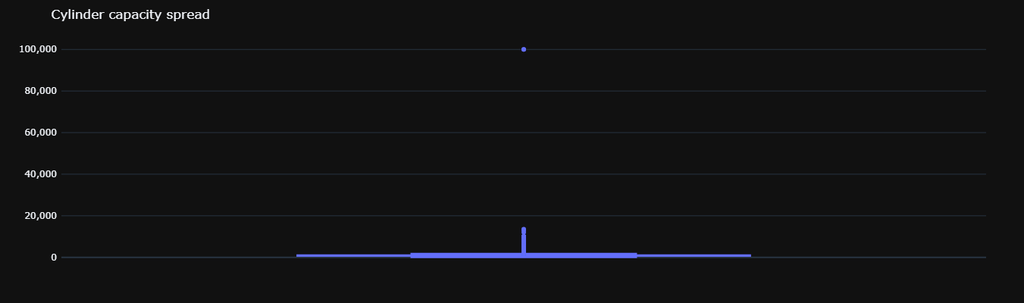

```python
fig = px.box(tr, y='cylinder_capacity', title='Cylinder capacity spread')
fig.update_layout(
    xaxis_title='',
    yaxis=dict(title='', tickformat=',.0f'),
    width=500,
    height=400,
    margin=dict(l=10,  r=50, t=50, b=0, pad=5)
)
fig.show(renderer="jupyterlab")
```

Using boxplot property to identify outliers, we see that cylinder capacity (cc) > 1856 are outliers. Let's dive deeper. We found out that one of the highest cc for motorcycle is 2458 (Triumph Rocket 3) so we'll check any value higher than 2500 but firstly we'll change "99999" to np.nan.

```python
tr.loc[tr['cylinder_capacity']>20000, 'cylinder_capacity'] = np.nan
```

```python
cc_outliers_upperbound = tr.loc[tr['cylinder_capacity']>2500]
cc_outliers_upperbound['cylinder_capacity'].values
```

```
<IntegerArray>
[ 7817,  7817,  7817,  7494,  7817,  7817,  2994,  9976,  9976,  7819,
 ...
 12009,  5499,  6509,  7817,  7817,  2647,  7817,  7817,  7817,  9976]
Length: 156, dtype: Int32
```

After a small research i found out that there is some descrepancy in numbers, a dot was missing for many values except for make "Boss Hoss", it has highest cylinder capacity value in table (5700, 8200), thereafter I will divide other values by 10.

```python
cc_outliers_upperbound = (cc_outliers_upperbound.sort_values(by='cylinder_capacity', ascending=False))
cc_outliers_upperbound = (
    cc_outliers_upperbound.loc[
        ~cc_outliers_upperbound['make'].isin(['LAND ROVER', 'LOTUS'])
        ]
)
cc_outliers_upperbound = (
    cc_outliers_upperbound.loc[
        ~cc_outliers_upperbound['make'].str.contains('(BOSS)|(V8)')]
)
cc_outliers_upperbound['cylinder_capacity'] = (
    (cc_outliers_upperbound['cylinder_capacity'] / 10).round(0)
)
tr.loc[cc_outliers_upperbound.index, 'cylinder_capacity'] = cc_outliers_upperbound['cylinder_capacity']
```

Considering lower bound is around 50 сс, i'll drop values lower than 40.

```python
tr.loc[tr['cylinder_capacity'] < 40, 'cylinder_capacity'] = np.nan
```

#### ['test_result'] column

If `['test_result']` is "P(Passed)" or "PRS(Passed with rectification)" it means the vehicle passed the test and won't appear in the table again. Let's check that.

```python
tr = tr.sort_values(by=['vehicle_id', 'completed_date'])
appear_after_pass = pd.DataFrame()
for i in range(10):
    test = tr.groupby('vehicle_id').nth(i)
    if test.empty:
        break
    passed_test = (
        test.loc[
            lambda x: x['test_result'].isin(['P','PRS']),
            'vehicle_id']
            .values
    )
    passed_but_have_second = (
        tr.loc[
            tr['vehicle_id'].isin(passed_test)]
          .groupby('vehicle_id',
                   as_index=False)
          .size()
          .sort_values(by='size', ascending=False)
          .loc[lambda x:x['size']>i+1]
                             )
    display(Markdown(
        f'{passed_but_have_second.shape[0]} vehicles passed '
        f'{i+1}th test but have consequent'))
    appear_after_pass = pd.concat([appear_after_pass, passed_but_have_second])
```

8473 vehicles passed 1th test but have consequent

507 vehicles passed 2th test but have consequent

19 vehicles passed 3th test but have consequent

1 vehicles passed 4th test but have consequent

0 vehicles passed 5th test but have consequent

```python
tr = tr.loc[~tr['vehicle_id'].isin(appear_after_pass['vehicle_id'])]
```

```python
# проверить, может еще есть случаи этого
tr = tr.drop(tr.loc[tr['vehicle_id'].isin([278099932, 323120436, 695051878])].index)
```

#### ['test_type'] column

According to test guide, first test for each vehicle is labeled as "NT(Full initial test)", if it's second, third and so on, it's "RT(Re-Test)".

```python
first_test = tr.groupby('vehicle_id').nth(0)
first_test['test_type'].value_counts()
```

```
test_type
NT    658727
RT       492
EI         0
ES         0
Name: count, dtype: int64
```

In some cases first test is labeled as "RT(Re-Test)", we don't know exactly, whether first test failed or took place last year, i would refer to each first test as a first one ("NT").

```python
first_test_rt_index = first_test.loc[lambda x: x['test_type']=='RT'].index
tr.loc[tr.index.isin(first_test_rt_index), 'test_type'] = 'NT'
```

Checking other tests

```python
other_test = tr.loc[~tr.index.isin(first_test.index)]
other_test['test_type'].value_counts()
```

```
test_type
RT    35876
NT     7329
EI        0
ES        0
Name: count, dtype: int64
```

Consquently i will refer to all tests except first one as "RT(Re-Test)"

```python
other_test_nt_index = other_test.loc[lambda x: x['test_type']=='NT'].index
tr.loc[tr.index.isin(other_test_nt_index), 'test_type'] = 'RT'
```

#### ['first_use_date'] column

According to MOT test guide, vehicles belonging to 2nd `['test_class_id']` have first test in 3 years after first use, so max `['first_use_date']` year should be 2021.

```python
less_than_three_years = tr.loc[tr['first_use_date'].dt.year > 2021]
display(Markdown(f'We have {less_than_three_years.shape[0]} motos, '
                 f'which were made in 2021 and later, it will be dropped.'))
tr = tr.drop(less_than_three_years.index)
```

[output not shown]

#### Other columns

As `['test_date']` always equals `['completed_date']` we don't need `['test_date']` column

```python
display(Markdown(f" Number of tests wasn't completed within a day: {(tr['test_date'].dt.day != tr['completed_date'].dt.day).sum()}"))
```

Number of tests wasn't completed within a day: 0

```python
tr = tr.drop('test_date', axis=1)
```

We have some motorcycles that were produced in 1920s, checking was its brand invented earlier.

```python
tr.loc[tr.index.isin(tr['first_use_date'].sort_values().index[:10])].sort_values(by='first_use_date')
```

|  | test_id | vehicle_id | test_type | test_result | test_mileage | postcode_area | make | model | cylinder_capacity | first_use_date | completed_date |
| --- | --- | --- | --- | --- | --- | --- | --- | --- | --- | --- | --- |
| 631386 | 474631409 | 359404640 | NT | P | 78637 | PO | HARLEY-DAVIDSON | UNCLASSIFIED | 1600 | 1900-01-01 | 2024-06-20 12:34:55 |
| 302644 | 1205523925 | 1378491057 | NT | P | <NA> | HX | HARLEY-DAVIDSON | UNKNOWN | 883 | 1901-01-01 | 2024-04-24 13:52:58 |
| 1003988 | 1678578807 | 1439959509 | NT | P | <NA> | SA | QUADRANT | UNCLASSIFIED | 225 | 1903-12-31 | 2024-10-10 09:48:12 |
| 959699 | 1807698951 | 488523726 | NT | P | <NA> | BN | MINERVA | M INERVA | 354 | 1904-12-31 | 2024-10-01 09:16:44 |
| 1043168 | 298055339 | 81591339 | NT | P | <NA> | IP | INDIAN MOTORCYCLE | UNCLASSIFIED | 540 | 1914-12-31 | 2024-11-13 13:17:23 |
| 709528 | 1888725645 | 115050107 | NT | P | <NA> | LE | IXION | UNCLASSIFIED | 269 | 1921-01-14 | 2024-07-27 08:20:39 |
| 819076 | 1751617031 | 167060881 | NT | P | <NA> | WF | RUDGE WHITWORTH | UNCLASSIFIED | <NA> | 1921-01-24 | 2024-08-06 14:03:47 |
| 111453 | 73839313 | 290423628 | NT | PRS | 2091 | IP | BSA | UNCLASSIFIED | 557 | 1921-09-30 | 2024-03-21 16:22:15 |
| 854500 | 1439707831 | 502866871 | NT | P | <NA> | IP | DOUGLAS | UNCLASSIFIED | 349 | 1923-01-06 | 2024-08-08 15:28:11 |
| 934607 | 1225139087 | 165306432 | NT | P | <NA> | IP | RALEIGH | MODEL NUMBER TWO | 275 | 1924-03-22 | 2024-09-05 15:50:37 |

"Harley-Davidson" was founded in 1903, so it isn't possible to have `['first_use_date']` < 1903, changing value to "pd.NaT"

```python
tr.loc[
    (tr['first_use_date'] < '1903-01-01')
    & (tr['make'] == 'HARLEY-DAVIDSON')
    ] = np.nan
```

Adding `'Age'` column for convenience

```python
tr['age'] = (tr['completed_date']-tr['first_use_date']).dt.days / 365.25
```

```python
tr['miles_per_year'] = (tr['test_mileage'] / tr['age']).round(2)
```

Checking `['test_mileage']` column

```python
(tr.loc[
    tr.index.isin(
        tr['test_mileage']
            .sort_values(ascending=False)
            .index[:10]
        )
    ]
    .sort_values(
        by='test_mileage',
        ascending=False
    )
)
```

|  | test_id | vehicle_id | test_type | test_result | test_mileage | postcode_area | make | model | cylinder_capacity | first_use_date | completed_date | age | miles_per_year |
| --- | --- | --- | --- | --- | --- | --- | --- | --- | --- | --- | --- | --- | --- |
| 90654 | 1968754287 | 563894602 | NT | P | 999999 | W | BMW | R SERIES | 1170 | 2006-03-14 | 2024-02-28 13:57:51 | 17.960301 | 55678.3 |
| 267382 | 193471355 | 1376301578 | NT | P | 999999 | BS | TRIUMPH | ROCKET III | 2294 | 2005-03-09 | 2024-04-09 08:55:35 | 19.085558 | 52395.59 |
| 224565 | 1013126419 | 499394821 | NT | PRS | 949647 | OL | HYOSUNG | GV 650 | 647 | 2013-08-01 | 2024-04-05 13:41:23 | 10.677618 | 88938.09 |
| 410506 | 1403084515 | 1184370198 | RT | P | 929990 | B | VICTORY | V92C | 1507 | 2001-12-31 | 2024-05-10 13:27:14 | 22.357290 | 41596.72 |
| 410504 | 436740687 | 1184370198 | NT | F | 929980 | B | VICTORY | V92C | 1507 | 2001-12-31 | 2024-05-07 14:56:39 | 22.349076 | 41611.56 |
| 579547 | 948259013 | 828568425 | NT | P | 884216 | EH | TRIUMPH | TIGER | 800 | 2018-09-07 | 2024-06-19 12:23:05 | 5.782341 | 152916.62 |
| 915827 | 79283157 | 1208199766 | NT | P | 820702 | NN | HONDA | ST1100 | 1099 | 1991-02-18 | 2024-09-30 09:40:05 | 33.615332 | 24414.51 |
| 372940 | 1246982309 | 278135049 | RT | P | 704364 | PE | KEEWAY | SUPERLIGHT | 125 | 2017-05-20 | 2024-05-09 19:20:46 | 6.970568 | 101048.29 |
| 924823 | 1352650589 | 8802450 | NT | P | 626639 | SO | SUZUKI | UNCLASSIFIED | 937 | 1994-07-23 | 2024-09-12 10:58:45 | 30.140999 | 20790.25 |
| 90869 | 1053332387 | 151082486 | NT | P | 612074 | ME | HYOSUNG | GV650 | 647 | 2007-03-15 | 2024-02-28 12:05:35 | 16.958248 | 36093.0 |

While it's almost impossible to check outliers in `['test_mileage']` column i'll change "999999" to "np.nan"

```python
tr.loc[tr['test_mileage'] == 999999, 'test_mileage'] = pd.NA
```

```python
#!!!!!!!!!!!!!!!!!!!1
```

```python
tr.loc[(tr['miles_per_year'] <= 200) & (tr['first_use_date'] < '1996-01-01'), 'test_mileage'] = pd.NA
```

```python
tr.loc[tr['miles_per_year'] <= 200, 'miles_per_year'] = np.nan
```

Adding simplified version of `['test_result']` column for convenience

```python
tr['passed'] = tr['test_result'].isin(['P', 'PRS'])
```

```python
display(Markdown(f"Initial table info"))
print(buffer.getvalue())
```

Initial table info

```
<class 'pandas.core.frame.DataFrame'>
RangeIndex: 1069066 entries, 0 to 1069065
Data columns (total 16 columns):
 #   Column             Non-Null Count    Dtype
---  ------             --------------    -----
 0   Unnamed: 0         1069066 non-null  int64
 1   test_id            1069066 non-null  int64
 2   vehicle_id         1069066 non-null  int64
 3   test_date          1069066 non-null  object
 4   test_class_id      1069066 non-null  int64
 5   test_type          1069066 non-null  object
 6   test_result        1069066 non-null  object
 7   test_mileage       1050502 non-null  float64
 8   postcode_area      1069066 non-null  object
 9   make               1069066 non-null  object
 10  model              1069062 non-null  object
 11  colour             1069066 non-null  object
 12  fuel_type          1069066 non-null  object
 13  cylinder_capacity  1067803 non-null  float64
 14  first_use_date     1069066 non-null  object
 15  completed_date     1069066 non-null  object
dtypes: float64(2), int64(4), object(10)
memory usage: 130.5+ MB
```

```python
display(Markdown(f"Table info after tranformation"))
tr.info()
```

Table info after tranformation

```
<class 'pandas.core.frame.DataFrame'>
Index: 700823 entries, 643925 to 829296
Data columns (total 14 columns):
 #   Column             Non-Null Count   Dtype
---  ------             --------------   -----
 0   test_id            700821 non-null  Int32
 1   vehicle_id         700821 non-null  Int32
 2   test_type          700821 non-null  category
 3   test_result        700821 non-null  category
 4   test_mileage       686502 non-null  Int32
 5   postcode_area      700821 non-null  string
 6   make               700821 non-null  string
 7   model              700820 non-null  string
 8   cylinder_capacity  700051 non-null  Int32
 9   first_use_date     700820 non-null  datetime64[ns]
 10  completed_date     700821 non-null  datetime64[ns]
 11  age                700820 non-null  float64
 12  miles_per_year     665083 non-null  Float64
 13  passed             700823 non-null  bool
dtypes: Float64(1), Int32(4), bool(1), category(2), datetime64[ns](2), float64(1), string(3)
memory usage: 58.8 MB
```

## 'Item Detail' table

```python
itde.head()
```

|  | rfr_id | test_class_id | test_item_id | minor_item | rfr_deficiency_category | rfr_desc | rfr_loc_marker | rfr_insp_manual_desc | rfr_advisory_text | test_item_set_section_id |
| --- | --- | --- | --- | --- | --- | --- | --- | --- | --- | --- |
| 0 | 4 | 1 | 3 | Y | Pre-EU Directive | missing | N | an obligatory lamp missing | NaN | 1 |
| 1 | 4 | 2 | 3 | Y | Pre-EU Directive | missing | N | an obligatory lamp missing | NaN | 1 |
| 2 | 5 | 1 | 3 | Y | Pre-EU Directive | damaged and function impaired | N | so damaged or deteriorated that its function i... | damaged but function not impaired | 1 |
| 3 | 5 | 2 | 3 | Y | Pre-EU Directive | damaged and function impaired | N | so damaged or deteriorated that its function i... | damaged but function not impaired | 1 |
| 4 | 6 | 1 | 3 | Y | Pre-EU Directive | deteriorated and function impaired | N | so damaged or deteriorated that its function i... | deteriorated but function not impaired | 1 |

```python
buffer = io.StringIO()
itde.info(buf=buffer)
```

Again, we don't need `['test_class_id']` column anymore, as well as some other columns, dropping it

```python
itde = itde.loc[itde['test_class_id'] == 2]
itde = itde.drop(columns=['test_class_id', 'rfr_desc',
                          'rfr_advisory_text', 'rfr_loc_marker'])
itde.rename(columns={'rfr_insp_manual_desc': 'rfr_desc'},
            inplace=True)
itde['minor_item']= itde['minor_item'].map({'Y': True, 'N': False})
```

```python
int_cols = ['rfr_id', 'test_item_id', 'test_item_set_section_id']
itde[int_cols] = itde[int_cols].astype('Int32')

itde['rfr_deficiency_category'] = (
    itde['rfr_deficiency_category'].astype('category')
)

itde['rfr_desc'] = itde['rfr_desc'].astype('string')
```

```python
print(buffer.getvalue())
```

```
<class 'pandas.core.frame.DataFrame'>
RangeIndex: 21069 entries, 0 to 21068
Data columns (total 10 columns):
 #   Column                    Non-Null Count  Dtype
---  ------                    --------------  -----
 0   rfr_id                    21069 non-null  int64
 1   test_class_id             21069 non-null  int64
 2   test_item_id              21069 non-null  int64
 3   minor_item                21069 non-null  object
 4   rfr_deficiency_category   21069 non-null  object
 5   rfr_desc                  21069 non-null  object
 6   rfr_loc_marker            21069 non-null  object
 7   rfr_insp_manual_desc      20911 non-null  object
 8   rfr_advisory_text         6824 non-null   object
 9   test_item_set_section_id  21069 non-null  int64
dtypes: int64(4), object(6)
memory usage: 1.6+ MB
```

```python
print(itde.info())
```

```
<class 'pandas.core.frame.DataFrame'>
Index: 1389 entries, 1 to 21068
Data columns (total 6 columns):
 #   Column                    Non-Null Count  Dtype
---  ------                    --------------  -----
 0   rfr_id                    1389 non-null   Int32
 1   test_item_id              1389 non-null   Int32
 2   minor_item                1389 non-null   bool
 3   rfr_deficiency_category   1389 non-null   category
 4   rfr_desc                  1367 non-null   string
 5   test_item_set_section_id  1389 non-null   Int32
dtypes: Int32(3), bool(1), category(1), string(1)
memory usage: 45.0 KB
None
```

## 'Test Item' table

```python
ti.head()
```

|  | Unnamed: 0 | test_id | rfr_id | rfr_type_code | mot_test_rfr_location_type_id | dangerous_mark | completed_date |
| --- | --- | --- | --- | --- | --- | --- | --- |
| 0 | 0 | 939637859 | 40098 | A | 9 | NaN | 2024-01-02T10:03:29.000Z |
| 1 | 1 | 939637859 | 40098 | A | 9 | NaN | 2024-01-02T10:03:29.000Z |
| 2 | 2 | 401677457 | 40450 | A | 25 | NaN | 2024-01-02T10:47:37.000Z |
| 3 | 3 | 401677457 | 40546 | A | 83 | NaN | 2024-01-02T10:47:37.000Z |
| 4 | 4 | 401677457 | 40663 | A | 5 | NaN | 2024-01-02T10:47:37.000Z |

```python
buffer = io.StringIO()
ti.info(buf=buffer)
ti.info()
```

```
<class 'pandas.core.frame.DataFrame'>
RangeIndex: 541185 entries, 0 to 541184
Data columns (total 7 columns):
 #   Column                         Non-Null Count   Dtype
---  ------                         --------------   -----
 0   Unnamed: 0                     541185 non-null  int64
 1   test_id                        541185 non-null  int64
 2   rfr_id                         541185 non-null  int64
 3   rfr_type_code                  541185 non-null  object
 4   mot_test_rfr_location_type_id  541185 non-null  int64
 5   dangerous_mark                 32999 non-null   object
 6   completed_date                 541185 non-null  object
dtypes: int64(4), object(3)
memory usage: 28.9+ MB
```

Dropping useless columns and duplicates because each separate test for vehicle has own id

```python
ti_unnamed_column = ti.iloc[:,0].name
ti.drop(columns=[ti_unnamed_column], inplace=True)
ti = ti.drop_duplicates(keep='first').reset_index(drop=True)
```

As we have "P(Passed)" value in `tr['test_result']` i'll change to "P" to "PRS(Pass with rectification)" in `ti['rfr_type_code']`

```python
ti['rfr_type_code'] = ti['rfr_type_code'].str.replace('P', 'PRS')
```

changing dtypes

```python
ti['completed_date'] = pd.to_datetime(ti['completed_date'])
ti['completed_date']  = ti['completed_date'].dt.tz_localize(None)

int_cols = ['test_id', 'rfr_id', 'mot_test_rfr_location_type_id']
ti[int_cols] = ti[int_cols].astype('Int32')
ti['rfr_type_code'] = ti['rfr_type_code'].astype('category')
```

#### ['Dangerous_mark'] column

There is confusing description for `['dangerous_mark']` column in MOT guide, we'll check if it's the same as category "Dangerous" in `itde['rfr_deficiency_category']`

```python
ti['dangerous_mark'].value_counts(dropna=False)
```

```
dangerous_mark
NaN    413758
D       27499
Name: count, dtype: int64
```

```python
ti_danger = ti.loc[ti['dangerous_mark'] =='D']
danger_tr = tr.merge(ti_danger, on='test_id', how='inner')
dang = danger_tr.merge(itde, on='rfr_id', how='left')
display(
    Markdown(
        f"{dang.loc[
            (dang['rfr_deficiency_category'] == 'Dangerous') &
            (dang['dangerous_mark']=='D')
            ]
                .shape[0]}"
         f" rows has both True for `ti['dangerous_mark']` and 'Dangerous' "
         f"for `itde['rfr_deficiency_category']` so i suspect that"
         f"`['dangerous_mark']` column duplicate "
         f"category 'Dangerous' so there is not need for it"
    )
)
```

26946 rows has both True for `ti['dangerous_mark']` and 'Dangerous' for `itde['rfr_deficiency_category']` so i suspect that`['dangerous_mark']` column duplicate category 'Dangerous' so there is not need for it

```python
ti = ti.drop(columns=['dangerous_mark'])
```

```python
display(Markdown(f"Initial table info"))
print(buffer.getvalue())
```

Initial table info

```
<class 'pandas.core.frame.DataFrame'>
RangeIndex: 541185 entries, 0 to 541184
Data columns (total 7 columns):
 #   Column                         Non-Null Count   Dtype
---  ------                         --------------   -----
 0   Unnamed: 0                     541185 non-null  int64
 1   test_id                        541185 non-null  int64
 2   rfr_id                         541185 non-null  int64
 3   rfr_type_code                  541185 non-null  object
 4   mot_test_rfr_location_type_id  541185 non-null  int64
 5   dangerous_mark                 32999 non-null   object
 6   completed_date                 541185 non-null  object
dtypes: int64(4), object(3)
memory usage: 28.9+ MB
```

```python
display(Markdown(f"Table info after tranformation"))
ti.info()
```

Table info after tranformation

```
<class 'pandas.core.frame.DataFrame'>
RangeIndex: 441257 entries, 0 to 441256
Data columns (total 5 columns):
 #   Column                         Non-Null Count   Dtype
---  ------                         --------------   -----
 0   test_id                        441257 non-null  Int32
 1   rfr_id                         441257 non-null  Int32
 2   rfr_type_code                  441257 non-null  category
 3   mot_test_rfr_location_type_id  441257 non-null  Int32
 4   completed_date                 441257 non-null  datetime64[ns]
dtypes: Int32(3), category(1), datetime64[ns](1)
memory usage: 10.1 MB
```

## 'Item group' table

```python
ig.head()
```

|  | test_item_id | test_class_id | parent_id | test_item_set_section_id | item_name |
| --- | --- | --- | --- | --- | --- |
| 0 | 0 | 1 | 0 | 0 | Vehicle |
| 1 | 0 | 2 | 0 | 0 | Vehicle |
| 2 | 0 | 3 | 0 | 0 | Vehicle |
| 3 | 0 | 4 | 0 | 0 | Vehicle |
| 4 | 0 | 5 | 0 | 0 | Vehicle |

```python
ig = ig.loc[ig['test_class_id'] == 2].drop(columns=['test_class_id'])
```

```python
int_cols = ig.select_dtypes(include='int').columns
ig[int_cols] = ig[int_cols].astype('Int32')

str_cols = ig.select_dtypes(exclude='int').columns
ig[str_cols] = ig[str_cols].astype('string')
```

```python
ig.info()
```

```
<class 'pandas.core.frame.DataFrame'>
Index: 316 entries, 1 to 4135
Data columns (total 4 columns):
 #   Column                    Non-Null Count  Dtype
---  ------                    --------------  -----
 0   test_item_id              316 non-null    Int32
 1   parent_id                 316 non-null    Int32
 2   test_item_set_section_id  316 non-null    Int32
 3   item_name                 316 non-null    string
dtypes: Int32(3), string(1)
memory usage: 9.6 KB
```

## 'Item Location' table

```python
rfr_loc.head()
```

|  | id | lateral | longitudinal | vertical |
| --- | --- | --- | --- | --- |
| 0 | 1 | NaN | NaN | NaN |
| 1 | 3 | Nearside | NaN | NaN |
| 2 | 5 | Offside | NaN | NaN |
| 3 | 7 | NaN | Front | NaN |
| 4 | 9 | NaN | Rear | NaN |

Filter to motorcycle items location only

```python
moto_rfr_loc_type_id = ti['mot_test_rfr_location_type_id'].unique()
rfr_loc = rfr_loc.loc[rfr_loc['id'].isin(moto_rfr_loc_type_id)]
```

# 3. Moto dataset analysis # изменить

## Some summary statistics

### Number of motorcycles passed the test by number of attempts

```python
display(Markdown(f"Number of motorcycles: {tr['vehicle_id'].nunique()}"))
display(Markdown(f"Number of brands: {tr['make'].nunique()}"))
```

Number of motorcycles: 657664

Number of brands: 908

```python
moto_num_by_test_num = (
    tr.groupby('vehicle_id',
            as_index=False)
      .size()
      .rename(columns={'size':'attempts_num'})
      ['attempts_num']
      .value_counts()
      .to_frame('number_of_moto')
)
moto_num_by_test_num
```

| attempts_num | number_of_moto |
| --- | --- |
| 1 | 615441 |
| 2 | 41336 |
| 3 | 842 |
| 4 | 43 |
| 5 | 2 |

```python
for test_num in range(4):
    test_result = (
        tr.sort_values(by=['vehicle_id',
                           'completed_date'])
          .groupby('vehicle_id')
          .nth(test_num)
          ['passed']
          .value_counts()
    )
    passed = test_result.get(True, 0)
    failed = test_result.get(False, 0)
    fail_pct = round(failed / (failed+passed)* 100,2)
    abandoned = 0
    if test_num > 0:
        pr_test_result = (
            tr.sort_values(by=['vehicle_id',
                               'completed_date'])
              .groupby('vehicle_id')
              .nth(test_num-1)
              ['passed']
              .value_counts()
        )
        pr_test_failed = pr_test_result.get(False, 0)
        abandoned = pr_test_failed - (passed + failed)
    fail_pct_str = f'{fail_pct:.2f}%'
    print(f'Test #{test_num+1}:')
    print(f'  Passed:     {passed:>8}')
    print(f'  Failed:     {failed:>8}')
    print(f'  Fail rate:  {fail_pct_str:>8}')
    print(f'  Abandoned:  {abandoned:>8}')
    print('')
```

```
Test #1:
  Passed:       612152
  Failed:        45512
  Fail rate:     6.92%
  Abandoned:         0

Test #2:
  Passed:        41244
  Failed:          979
  Fail rate:     2.32%
  Abandoned:      3289

Test #3:
  Passed:          839
  Failed:           48
  Fail rate:     5.41%
  Abandoned:        92

Test #4:
  Passed:           43
  Failed:            2
  Fail rate:     4.44%
  Abandoned:         3
```

Interestingly, we see that some motos didn't take attempt after failing the test(Abandoned). We would try to dive deeper for reasons of it.

```python
tr['test_result'].value_counts()
```

```
test_result
P        620902
F         44743
PRS       33378
ABR        1646
ABA         151
ABRVE         1
Name: count, dtype: int64
```

```python
display(
    Markdown(
        f"Out of all results we have {tr['test_result'].value_counts()['ABR']}"
        f" tests that were aborted(i.e test cannot be completed because of a problem "
        f" with the testing equipment or the NT). Let's check what finally happened to them."))
```

Out of all results we have 1646 tests that were aborted(i.e test cannot be completed because of a problem with the testing equipment or the NT). Let's check what finally happened to them.

```python
abrt_moto_vals = tr.loc[tr['test_result']=='ABR', 'vehicle_id'].values
abrt_moto = tr.loc[tr['vehicle_id'].isin(abrt_moto_vals)]
abrt_moto_last_test = (
    abrt_moto.sort_values(
        by=['vehicle_id',
        'completed_date'])
    .groupby('vehicle_id')
    .last()
)
abrt_moto_last_test['test_result'].value_counts()
```

```
test_result
P        1391
ABR       142
PRS        88
F           5
ABA         0
ABRVE       0
Name: count, dtype: int64
```

```python
# вбить в chatgpt что это за дичь
# (tr.loc[tr['vehicle_id'].isin(abrt_moto_last_test.loc[lambda x: x['test_result']=='ABR'].index)]['vehicle_id'].value_counts(
# ) > 1).sum()
```

```python
display(
    Markdown(
        f"We have {abrt_moto_last_test['test_result'].value_counts()['ABR']}"
        f" motos which test was aborted and they didn't retake it.")
)
```

We have 142 motos which test was aborted and they didn't retake it.

### Free or partial fee retest

```python
# отличие между dangerous и major
# https://www.gov.uk/getting-an-mot/after-the-test взять отсюда инфу и оставить ссылку
# отредактировать раздел с бесплатным ретестом, так как машину нельзя увозить если у нее есть dangerous category fail
```

In [official goverment services website](https://www.gov.uk/getting-an-mot/retests) it's said there is either no fee for vehicle owners who need a partial retest if they leave the vehicle at the test centre for repair and it’s retested within 10 working days or partial fee if the owner takes the vehicle from the test centre for repairs and takes it back within 10 working days. The caveat is, according to [official goverment services website](https://www.gov.uk/getting-an-mot/after-the-test) owner of the vehicle can take it away if his/her current MOT is still valid and "dangerous" problems were listed. in the MOT Let's check how many vehicles get free retest/discount. It means we'll count how many days passed after the test before retest.

```python
more_than_one_test = (
    tr.loc[
        tr['vehicle_id'].isin(
            tr.groupby('vehicle_id').size()
            [tr.groupby('vehicle_id').size() > 1]
            .index
        )
    ]
    .sort_values(by=['vehicle_id', 'completed_date'])
)
```

```python
def busday_diff(date_list):
    diff_list = []
    for idx in range(len(date_list) - 1):
        start = date_list[idx].to_numpy().astype('datetime64[D]')
        end = date_list[idx+1].to_numpy().astype('datetime64[D]')
        diff = np.busday_count(start, end, weekmask=[1,1,1,1,1,1,0])
        diff_list.append(diff)
    return diff_list
days_num_between_tests = (
    more_than_one_test
        .groupby('vehicle_id')['completed_date']
        .agg(list)
        .apply(busday_diff)
        .reset_index(name='days_num')
)
days_num_between_tests = days_num_between_tests.explode('days_num')
paid_retest = (
    days_num_between_tests.loc[days_num_between_tests['days_num'] > 10].shape[0]
)
free_retest = (
    days_num_between_tests.loc[
        days_num_between_tests['days_num'] <= 10
        ].shape[0]
)
display(
    Markdown(
        f"{free_retest} of {days_num_between_tests.shape[0]}"
        f" motos get no fee or partial fee retest"))
```

36708 of 43157 motos get no fee or partial fee retest

### Number of tests by month

Now we would like to know, how many tests were taken each month.

```python
tests_by_month = (
    tr.groupby([
        tr['completed_date'].dt.month,
        tr['completed_date'].dt.strftime('%b')
    ])
    .size()
    .droplevel(level=0)
)
tests_by_month = (
    tests_by_month.reset_index(name='test_num')
    .rename(columns={'completed_date': 'month'})
)
```

```python
fig = px.line(
    tests_by_month,
    x='month',
    y='test_num',
    title="Number of tests by month",
    markers=True
)
fig.update_layout(
    xaxis_title='',
    yaxis = dict(
        title='',
        tickmode = 'linear',
        tick0 = 0,
        dtick = 20000,
        tickformat=',.0f'
    )
)
fig.show()
```

[output not shown]

```python
tests_by_day = (
tr.groupby(
    [tr['completed_date'].dt.dayofweek,
    tr['completed_date'].dt.day_name()
    ])
  .agg(test_num=pd.NamedAgg(
          column="completed_date",
          aggfunc="size"
          )
    )
    .droplevel(level=0)
    .reset_index()
    .rename(columns={'completed_date': 'day'})
)
```

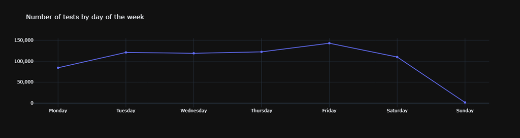

```python
fig = px.line(
    tests_by_day,
    x='day',
    y='test_num',
    title="Number of tests by day of the week",
    markers=True
)
fig.update_layout(
    xaxis_title='',
    yaxis=dict(
        title='',
        tickformat=',.0f'
    )
)
fig.show()
```

```python
# возможно дописать что-то по поводу дня недели теста
```

Let's check the time of test completion

```python
completion_time = (
    tr['completed_date'].dropna()
    .dt.hour
    .value_counts()
    .sort_index()
    .rename_axis('hour')
    .reset_index()
)
out_of_worktime_perc = (
    completion_time.loc[
        (completion_time['hour'] < 8)
        | (completion_time['hour'] > 17),
        'count'
    ].sum()
    / completion_time['count'].sum()
)
completion_time['hour'] = completion_time['hour'].astype(str).str.zfill(2)+':00'
```

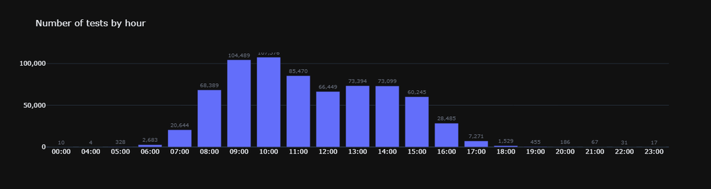

```python
fig = px.bar(
    completion_time,
    y='count',
    x='hour',
    title="Number of tests by hour",
    text_auto=True
)

fig.update_layout(
    # height=450,
    yaxis=dict(
        title='',
        tickformat=',.0f'
    ),
    xaxis=dict(
        title=''
    )
)
fig.update_traces(
    textposition='outside',
    textfont_size=10,
    textfont_color='#6B7280'
)
fig.show(renderer="jupyterlab")
```

```python
display(
    Markdown(
        f"Assuming approximate work time for VTS (from 8:00-8:30 till"
        f" 17:00-17:30) we can see around {out_of_worktime_perc:.2%} "
        f" of tests were completed after-hours or some values were entered"
        f" by mistake (04:00 instead of 16:00). Unfortunately, we miss some"
        f" data for further analysis, for example, start time of the test.")
)
```

Assuming approximate work time for VTS (from 8:00-8:30 till 17:00-17:30) we can see around 3.70% of tests were completed after-hours or some values were entered by mistake (04:00 instead of 16:00). Unfortunately, we miss some data for further analysis, for example, start time of the test.

From now on, we will work with the results of first test, because it's the most important one, you as a vehicle owner may not be aware about all problems with your vehicle.

```python
first_test = tr.loc[tr['test_type']=='NT']
```

### First test fail rate by month

Now we'll check does month of first test matter i.e. is there a difference in results between months?

```python
first_test_by_month = (
    first_test.groupby(
        [first_test['completed_date'].dt.month.rename('month_num'),
         first_test['completed_date'].dt.strftime('%b').rename('month_name'),
         'passed'
        ]
    )
    .agg(count=pd.NamedAgg(
        column="passed",
        aggfunc="count"
        )
    )
    .pivot_table(
        index='month_name',
        columns='passed',
        values='count',
        aggfunc='sum',
        sort=False
    )
)
first_test_fail_rate_by_month = first_test_by_month.copy()
first_test_fail_rate_by_month.columns.name = None
first_test_fail_rate_by_month = first_test_fail_rate_by_month.reset_index()
first_test_fail_rate_by_month['tot'] = (
    first_test_fail_rate_by_month[True] + first_test_fail_rate_by_month[False]
)
first_test_fail_rate_by_month['fail_rate'] = (
    first_test_fail_rate_by_month[False] / first_test_fail_rate_by_month['tot']
)
```

```python
# исправить школу %, чтобы начиналась с 0, исправить % в hover
```

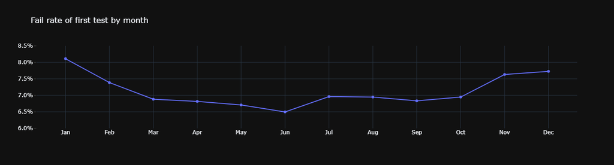

```python
fig = px.line(
    first_test_fail_rate_by_month,
    y='fail_rate',
    x='month_name',
    title="Fail rate of first test by month",
    markers=True
)
fig.update_layout(
    yaxis=dict(
        title='',
        tickformat='.1%',
        tickmode='linear',
        tick0=0.06,
        dtick=0.005,
        ticks='outside',
        range=[0.06, 0.085],
    ),
    xaxis=dict(title='')
)

fig.show(renderer="jupyterlab")
```

Interestingly, fail rate differs by month and visually there is some negative correlation between number of vehicles and fail rate. We'll check is it by random change or some dependency is taken place by computation the chi-square statistic and p-value for the hypothesis test of independence of the observed frequencies in our contigency table. Our null hypothesis is there is no difference in results across months.

```python
from scipy.stats import chi2_contingency

print('Contigency table')
print(first_test_by_month)
chi2, p_value, dof, expected = chi2_contingency(first_test_by_month)

print("\nChi-Square Test results:")
print(f"Chi2 Test Statistic: {chi2}")
print(f"P-value: {p_value}")
print(f"Degrees of Freedom (dof): {dof}")

alpha = 0.05
if p_value < alpha:
    print(f"Because p-value ({p_value:.4f}) < 0.05, we reject null hypothesis.")
    print("The difference in test fail rates between months is statistically significant.")
else:
    print(f"Because p-value ({p_value:.4f}) >= 0.05, we fail to reject null hypothesis.")
    print("We haven't enough evidence to say the difference is significant. It could be chance.")
```

```
Contigency table
passed      False  True
month_name
Jan          1488  16860
Feb          2896  36313
Mar          4941  66849
Apr          5139  70243
May          7117  98989
Jun          5425  78087
Jul          5149  68824
Aug          4260  57065
Sep          3388  46180
Oct          2945  39450
Nov          1742  21085
Dec          1022  12207

Chi-Square Test results:
Chi2 Test Statistic: 117.7970698295303
P-value: 5.0255875102044505e-20
Degrees of Freedom (dof): 11
Because p-value (0.0000) < 0.05, we reject null hypothesis.
The difference in test fail rates between months is statistically significant.
```

```python
## перенести вниз
# (~first_test.loc[first_test['test_result']=='P', 'test_id'].isin(ti['test_id'])).sum()
```

### Comparison test result from London vs Edinbough/Glasgow

Let's compare vehicles' test results from London and Edinbourgh, Glasgow, does the location & weather make impact on vehicles condition.

```python
london_edinbourgh_glasgow_postcode_areas = ["E", "EC", "N", "NW", "SE",
                                            "SW", "W", "WC", "EH", "G"]
edinbourgh_glasgow_postcode_areas = ["EH", "G"]
south_north_test = first_test.loc[
    first_test['postcode_area']
        .isin(london_edinbourgh_glasgow_postcode_areas
    )
]
south_north_test['location'] = np.where(
    south_north_test['postcode_area']
        .isin(edinbourgh_glasgow_postcode_areas),
             'Edinbourgh/Glasgow', 'London'
)
south_north_pivot = (south_north_test.groupby(
    'location', as_index=False)['passed']
    .value_counts()
    .pivot_table(index='location', columns='passed',
                 values='count', aggfunc='sum'))
south_north_pivot
```

| passed location | False | True |
| --- | --- | --- |
| Edinbourgh/Glasgow | 868 | 13467 |
| London | 1315 | 19784 |

```python
chi2, p_value, dof, expected = chi2_contingency(south_north_pivot)

print("\nChi-Square Test results:")
print(f"Chi2 Test Statistic: {chi2}")
print(f"P-value: {p_value}")
print(f"Degrees of Freedom (dof): {dof}")

alpha = 0.05
if p_value < alpha:
    print(f"Because p-value ({p_value:.4f}) < 0.05, we reject null hypothesis.")
    print("The difference in test fail rates between locations is statistically significant.")
else:
    print(f"Because p-value ({p_value:.4f}) >= 0.05, we fail to reject null hypothesis.")
    print("We haven't enough evidence to say the difference between locations is significant.")
```

```
Chi-Square Test results:
Chi2 Test Statistic: 0.4345395712708899
P-value: 0.5097698154332909
Degrees of Freedom (dof): 1
Because p-value (0.5098) >= 0.05, we fail to reject null hypothesis.
We haven't enough evidence to say the difference between locations is significant.
```

It's colder, windier and more humid on north and the fact that Edinbourgh is located near the sea, so vehicles could be inflicted more by corrosion, despite so to say opposite location, the difference in test result is not significant.

### Do certain regions have older vehicles on average & does the fail rate differ throughout regions?

We will try to get approximate area distribution where tests were taken place, despite having only high level postcode. I'll download postcode area latitude and longitude from Free Map Tools to visualize it.

```python
uk_coordinates = pd.read_csv(r'https://data.freemaptools.com/download/uk-outcode-postcodes/postcode-outcodes.csv', index_col='id')
uk_coordinates['postcode'] = uk_coordinates['postcode'].str.extract(r'(^[A-Z]{1,2})')
centroids = uk_coordinates.groupby('postcode', as_index=False)[['latitude', 'longitude']].mean()
```

To get postcode full name, i'll download table from [Wikipedia article](https://en.wikipedia.org/wiki/List_of_postcode_areas_in_the_United_Kingdom). It provides number of districts within area so it will be used as well.

```python
from io import StringIO
postcode_url = "https://en.wikipedia.org/wiki/List_of_postcode_areas_in_the_United_Kingdom"
headers = {
    'User-Agent': 'Mozilla/5.0 (Windows NT 10.0; Win64; x64) AppleWebKit/537.36 (KHTML, like Gecko) Chrome/91.0.4472.124 Safari/537.36'
}
try:
    response = requests.get(postcode_url, headers=headers)
    response.raise_for_status()
    html_content = response.text

    postcodes = pd.read_html(StringIO(html_content))[0]
    postcodes.columns = postcodes.columns.str.lower().str.replace(' ', '_')
    postcodes['districts_num_within_area'] = postcodes['number_of_postcode_districts_within_area'].str.split('(').str[0]
    postcodes = postcodes[['postcode_area', 'code_formation', 'districts_num_within_area']]
except requests.exceptions.HTTPError as err:
    print(f"HTTP error occurred: {err}")
except Exception as err:
    print(f"An error occurred: {err}")
postcodes.head()
```

|  | postcode_area | code_formation | districts_num_within_area |
| --- | --- | --- | --- |
| 0 | AB | Aberdeen | 33 |
| 1 | AL | St Albans | 10 |
| 2 | B | Birmingham | 79 |
| 3 | BA | Bath | 19 |
| 4 | BB | Blackburn | 13 |

```python
geo = (postcodes.merge(centroids,
           left_on='postcode_area',
           right_on='postcode',
           how='left')
    [['postcode_area', 'code_formation',
      'latitude', 'longitude',
      'districts_num_within_area']])
geo.head()
```

|  | postcode_area | code_formation | latitude | longitude | districts_num_within_area |
| --- | --- | --- | --- | --- | --- |
| 0 | AB | Aberdeen | 57.264839 | -2.440001 | 33 |
| 1 | AL | St Albans | 51.777545 | -0.271277 | 10 |
| 2 | B | Birmingham | 52.457823 | -1.883388 | 79 |
| 3 | BA | Bath | 51.164461 | -2.459054 | 19 |
| 4 | BB | Blackburn | 53.802076 | -2.311302 | 13 |

```python
first_test_by_area = (
    first_test.groupby('postcode_area',as_index=False)
    .agg(
        test_num=('passed', 'size'),
        passed=('passed', 'sum'),
        median_age=('age', 'median')
    )
)
first_test_by_area['median_age'] = first_test_by_area['median_age'].round(2)
first_test_by_area['fail_rate'] = (1-first_test_by_area['passed'] / first_test_by_area['test_num']).round(3)
first_test_by_area_merged = first_test_by_area.merge(geo, on='postcode_area')
first_test_by_area_merged.head()
```

|  | postcode_area | test_num | passed | median_age | fail_rate | code_formation | latitude | longitude | districts_num_within_area |
| --- | --- | --- | --- | --- | --- | --- | --- | --- | --- |
| 0 | AB | 5568 | 5184 | 12.05 | 0.069 | Aberdeen | 57.264839 | -2.440001 | 33 |
| 1 | AL | 2326 | 2227 | 10.64 | 0.043 | St Albans | 51.777545 | -0.271277 | 10 |
| 2 | B | 11139 | 10422 | 12.96 | 0.064 | Birmingham | 52.457823 | -1.883388 | 79 |
| 3 | BA | 7164 | 6418 | 13.84 | 0.104 | Bath | 51.164461 | -2.459054 | 19 |
| 4 | BB | 4046 | 3846 | 12.35 | 0.049 | Blackburn | 53.802076 | -2.311302 | 13 |

```python
first_test_by_area_merged[['median_age', 'fail_rate']].corr()
```

|  | median_age | fail_rate |
| --- | --- | --- |
| median_age | 1.000000 | 0.144123 |
| fail_rate | 0.144123 | 1.000000 |

[figure not shown]

```python
fig = px.scatter_map(
    first_test_by_area_merged,
    title='Fail rate by area',
    lat="latitude",
    lon="longitude",
    size="test_num",
    color="fail_rate",
    color_continuous_scale="Agsunset",
    hover_name="code_formation",
    hover_data={
        "latitude": False,
        "longitude": False,
        "districts_num_within_area": True,
        "median_age": True,
        "test_num": True,
        "fail_rate": ':.2%'
    },
    map_style='open-street-map',
    zoom=5
)
fig.update_layout(
    width=600,
    height=600,
    xaxis=dict(title=''),
    coloraxis_colorbar=dict(tickformat='.0%', title='fail rate'),
    coloraxis=dict(reversescale=True)
)

fig.show()
```

1. Older Motorcycle Fleet

Rural and coastal areas in the South-West tend to have older vehicles on average.

Many residents ride seasonally or for leisure, so their bikes might sit unused for long stretches — which can lead to corrosion, tyre degradation, and brake issues that increase fail rates.

By contrast, urban commuters (e.g., London area) often maintain newer, regularly serviced bikes.

🌧️ 2. Climate and Coastal Conditions

The South-West is more exposed to rain, salty sea air, and humidity, especially Cornwall and Devon.

Salt accelerates rusting and corrosion on metal components (brake lines, frames, exhausts), which are frequent MOT failure points.

Damp conditions can also affect electrics and tyres.

🧰 3. Maintenance Culture & Access to Services

There are fewer large motorcycle dealerships or service centers in rural Cornwall, Devon, and Somerset.

Riders may be more likely to do their own maintenance or delay professional servicing — which can lead to higher fail rates at formal MOT testing.

🛣️ 4. Road Use Patterns

Roads in the South-West are narrow, twisty, and rural, often with more debris, mud, and uneven surfaces.

That can lead to wear and tear on tyres and suspension, and also cause damage that’s not obvious until MOT inspection.

💷 5. Economic Factors

Some South-West regions have lower average incomes, which can mean riders postpone maintenance or rely on cheaper second-hand bikes.

Older, budget motorcycles are statistically more likely to fail MOTs.

📊 6. Testing Behaviour

MOT centers differ in how strict they are.

In smaller towns, a few local garages might dominate testing — if they’re especially rigorous (or if local riders use them late in the maintenance cycle), that can raise the local fail rate.

### Count of motorycles by decade of first use

Let's visualize, how many motos were used first time by decade, firstly we need create bins.

```python
decade_bins = pd.cut(first_test['first_use_date'].dt.year,
                     range(1920, 2031, 10),
                     right=False,
                     labels=["1920-1930", "1930-1940",
                             "1940-1950","1950-1960",
                             "1960-1970","1970-1980",
                             "1980-1990","1990-2000",
                             "2000-2010", "2010-2020", "2020-2021"])
moto_num_by_decade = (
    decade_bins.value_counts()
    .reset_index(name='moto_num')
    .sort_values(by='first_use_date')
)
```

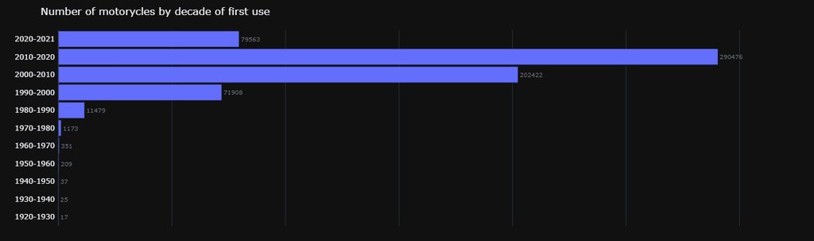

```python
max_value = moto_num_by_decade['moto_num'].max()
buffer = max_value * 0.10
x_axis_range = [0, max_value + buffer]

fig = px.bar(
    moto_num_by_decade,
    y='first_use_date',
    x='moto_num',
    title="Number of motorycles by decade of first use",
    orientation='h'
)

fig.update_layout(
    yaxis=dict(
        title='',
        tickformat=',.0f'
    ),
    xaxis=dict(
        title='',
        showticklabels=False,
        range=x_axis_range
    ),
    bargap=0.1,
    width=900,
    height=400,
    margin=dict(l=10, r=50, t=50, b=0, pad=5)
)

fig.update_traces(
    texttemplate='%{x:.0f}',
    textposition='outside',
    hoverinfo='skip',
    hovertemplate=None,
    textfont_size=10,
    textfont_color='#6B7280'
)

fig.show(config={"responsive": True}, renderer="jupyterlab")
```

```python
# можно чекнуть, какие результаты теста старых мото, до 1980
```

### Fail rate by motocycles' first year of use

Next we'll check does the fail rate deviate between different year of first use.

```python
fail_rate_by_first_use_year = (
    first_test[['first_use_date', 'passed']]
        .groupby(
            first_test['first_use_date'].dt.year.rename('year'),
            as_index=False
        )
        ['passed']
        .value_counts()
        .pivot_table(
            index='year',
            columns='passed',
            values='count',
            fill_value=0
        )
        .astype(int)
        .reset_index()
        .rename(
            columns={
                True:'passed',
                False: 'failed'}
        )
        .set_index(
            'year',
            drop=True
        )
)

fail_rate_by_first_use_year['test_num'] = (
    fail_rate_by_first_use_year['failed']
    + fail_rate_by_first_use_year['passed']
)
fail_rate_by_first_use_year.index = (
    fail_rate_by_first_use_year.index.astype('int')
)
fail_rate_by_first_use_year['fail_rate'] = (
    fail_rate_by_first_use_year['failed']
    / (fail_rate_by_first_use_year['failed']
    + fail_rate_by_first_use_year['passed'])
    ).round(3)
```

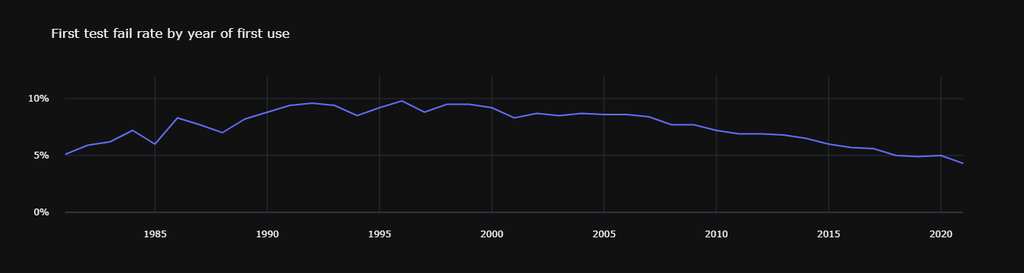

```python
fail_rate_by_first_use_year = (
    fail_rate_by_first_use_year.loc[
        fail_rate_by_first_use_year['test_num'] >= 400]
)

fig = px.line(
    fail_rate_by_first_use_year,
    y='fail_rate',
    title='First test fail rate by year of first use',
    hover_data={"fail_rate": ':.1%'})
fig.update_layout(
    yaxis=dict(
        title='',
        tickformat=".0%",
        range=[0, 0.12]
    ),
    xaxis=dict(title=''),
    margin=dict(pad=20)
)
fig.update_yaxes(rangemode="tozero")

fig.show()
```

Until 1998 fail rate is quite unstable year by year but then fail rate gradually decreases which support obvious statement that older vehicles are more prone to breakedowns.

### Fail rate by miles per year

```python
(first_test[['miles_per_year', 'passed']].groupby(
    first_test['miles_per_year'].round(-2),
    as_index=False)
    ['passed']
    .value_counts()
    .pivot_table(
        index='miles_per_year',
        columns='passed',
        values='count',
        fill_value=0
        )
    )
```

| passed miles_per_year | False | True |
| --- | --- | --- |
| 200.0 | 350.0 | 8009.0 |
| 300.0 | 883.0 | 19365.0 |
| 400.0 | 1049.0 | 22737.0 |
| 500.0 | 1291.0 | 25065.0 |
| 600.0 | 1345.0 | 27511.0 |
| ... | ... | ... |
| 52600.0 | 0.0 | 1.0 |
| 55700.0 | 0.0 | 1.0 |
| 56400.0 | 0.0 | 1.0 |
| 88900.0 | 0.0 | 1.0 |
| 152900.0 | 0.0 | 1.0 |

287 rows × 2 columns

```python
fail_rate_by_miles_per_year = (
    first_test[['miles_per_year', 'passed']]
        .groupby(
            first_test['miles_per_year'].round(-2),
            as_index=False
        )
        ['passed']
        .value_counts()
        .pivot_table(
            index='miles_per_year',
            columns='passed',
            values='count',
            fill_value=0
        )
        .astype(int)
        .reset_index()
        .rename(
            columns={
                True:'passed',
                False: 'failed'}
        )
        .set_index(
            'miles_per_year',
            drop=True
        )
)

fail_rate_by_miles_per_year['test_num'] = (
    fail_rate_by_miles_per_year['failed']
    + fail_rate_by_miles_per_year['passed']
)
fail_rate_by_miles_per_year.index = (
    fail_rate_by_miles_per_year.index.astype('int')
)
fail_rate_by_miles_per_year['fail_rate'] = (
    fail_rate_by_miles_per_year['failed']
    / (fail_rate_by_miles_per_year['failed']
    + fail_rate_by_miles_per_year['passed'])
    ).round(3)
```

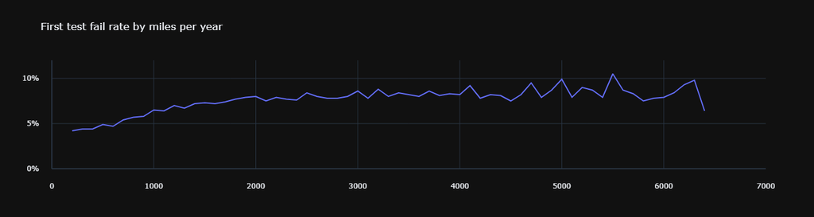

```python
fail_rate_by_miles_per_year = (
    fail_rate_by_miles_per_year.loc[
        fail_rate_by_miles_per_year['test_num'] >= 400]
)

fig = px.line(
    fail_rate_by_miles_per_year,
    y='fail_rate',
    title='First test fail rate by miles per year',
    hover_data={"fail_rate": ':.1%'})
fig.update_layout(
    yaxis=dict(
        title='',
        tickformat=".0%",
        range=[0, 0.12]
    ),
    xaxis=dict(
        title='',
        range=[0,7000]
    ),
    margin=dict(pad=20)
)
fig.update_yaxes(rangemode="tozero")

fig.show()
```

### Fail rate by brand

```python
fail_rate_by_make = (
    first_test.groupby(['make', 'passed'], as_index=False)
    .size()
    .pivot_table(
        index='make',
        columns='passed',
        values='size',
        fill_value=0)
    .astype('int')
)
fail_rate_by_make.columns.name = None
fail_rate_by_make = (
    fail_rate_by_make.reset_index(names='make')
    .rename(columns={True:'passed',
                     False: 'failed'})
)
fail_rate_by_make['test_num'] = (
    fail_rate_by_make['failed'] + fail_rate_by_make['passed']
)
fail_rate_by_make['fail_rate'] = (
    (fail_rate_by_make['failed']
    / (fail_rate_by_make['failed'] + fail_rate_by_make['passed']))
    .round(3)
)
fail_rate_by_make = fail_rate_by_make.loc[fail_rate_by_make['test_num'] >= 400]
fail_rate_by_make = fail_rate_by_make.sort_values(by='fail_rate')
```

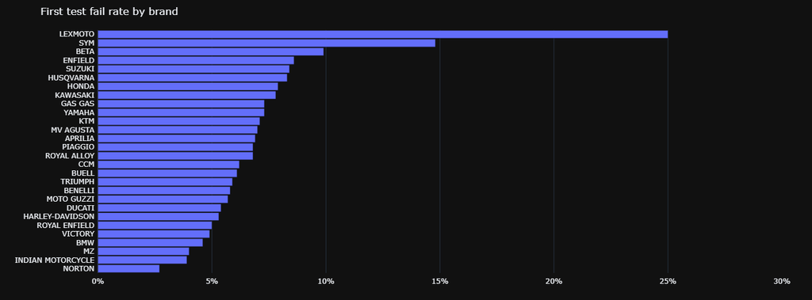

```python
fig = px.bar(
    fail_rate_by_make,
    y='make',
    x='fail_rate',
    title="First test fail rate by brand",
    orientation='h',
    hover_data={
        "make": False,
        "test_num": True,
        "fail_rate": ':.2%'
    },
)
fig.update_layout(
    yaxis=dict(title=''),
    xaxis=dict(
        title='',
        showticklabels=True,
        tickformat='.0%',
        range=[0, 0.3],

    ),
    bargap=0.1,
    width=900,
    height=500,
    margin=dict(l=10,
                r=50,
                t=50,
                b=0,
                pad=5)
)

fig.show()
```

```python
top_10_makers = first_test['make'].value_counts()[:10].index.to_list()
top_5_makers_first_test = first_test.loc[first_test['make'].isin(top_10_makers[:5])]
year_bins = pd.cut(top_5_makers_first_test['age'],
                   bins=[0,5,10,15,20,30,40,120],
                   labels=['<5', '5-10', '10-15', '15-20',
                           '20-30', '30-40', '40+'])
top_5_makers_by_age = (
    top_5_makers_first_test.groupby(
        ['make', year_bins],
        as_index=False,
        observed=False)['passed']
    .value_counts()
    .pivot_table(
        columns='passed',
        values='count',
        index=['make', 'age'],
        fill_value=0,
        observed=False)
    .astype('int')
)
top_5_makers_by_age.columns.name = None
top_5_makers_by_age = (
    top_5_makers_by_age.reset_index()
    .rename(columns={True:'passed', False: 'failed'})
)
top_5_makers_by_age['test_num'] = (
    top_5_makers_by_age['failed'] + top_5_makers_by_age['passed']
)
top_5_makers_by_age['fail_rate'] = (
    (top_5_makers_by_age['failed'] / top_5_makers_by_age['test_num']).round(3)
)
```

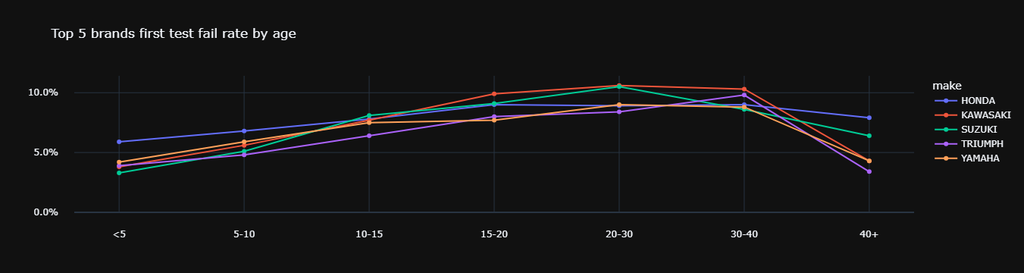

```python
fig = px.line(
    top_5_makers_by_age,
    x='age',
    y='fail_rate',
    color='make',
    title='Top 5 brands first test fail rate by age',
    markers=True
)
fig.update_layout(
    yaxis=dict(
        title='',
        tickformat=".1%",
    ),
    xaxis=dict(title=''),
    margin=dict(pad=20)
)
fig.update_yaxes(rangemode="tozero")
fig.show()
```

### Fail rate by mileage

Let's check whether fail rate deviate depends on mileage of moto. We will create custom bins for groupping mileage.

```python
first_test['top5_make_or_other'] = (
    np.where(
        first_test['make'].isin(top_10_makers[:5]),
        first_test['make'],
        'OTHER BRANDS'
    )
)
mileage_bins = pd.cut(
    first_test['test_mileage'],
    [0, 10000, 30000, 60000, 90000, np.inf],
    right=False,
    labels=["0-10000", "10000-30000",
            "30000-60000", "60000-90000",
             "90000+"]
)
top_5_and_other_brands_by_mileage = (
    first_test.groupby(
        ['top5_make_or_other', mileage_bins],
        as_index=False,
        observed=False)['passed']
    .value_counts()
    .pivot_table(
        columns='passed',
        values='count',
        index=['top5_make_or_other', 'test_mileage'],
        fill_value=0,
        observed=False)
    .astype('int')
)
top_5_and_other_brands_by_mileage.columns.name = None
top_5_and_other_brands_by_mileage = (
    top_5_and_other_brands_by_mileage.reset_index()
    .rename(columns={True:'passed', False: 'failed'})
)
top_5_and_other_brands_by_mileage['test_num'] = (
    top_5_and_other_brands_by_mileage['failed'] + top_5_and_other_brands_by_mileage['passed']
)
top_5_and_other_brands_by_mileage['fail_rate'] = (
    (top_5_and_other_brands_by_mileage['failed'] / top_5_and_other_brands_by_mileage['test_num']).round(3)
)
```

```python
fig = px.line(
    top_5_and_other_brands_by_mileage,
    x='test_mileage',
    y='fail_rate',
    color='top5_make_or_other',
    title='Top 5 brands first test fail rate by mileage vs others',
    markers=True,
    category_orders={
        "top5_make_or_other": ["HONDA", "YAMAHA", "TRIUMPH", "SUZUKI", "KAWASAKI", "OTHER BRANDS"]
    }
)
fig.update_layout(
    legend_title_text='brand',
    yaxis=dict(
        title='',
        tickformat=".1%",
        range=[0, 0.15]
    ),
    xaxis=dict(
        title='',
        showticklabels=True,
    )
)
fig.show()
```

[output not shown]

Again we have obvious assertion, vehicles with higher mileage tend to fail the test more often due to deterioration.

### Fail rate by cylinder capacity

Let's check another guess, does cylinder capacity have any influence on test result?

```python
fail_rate_by_cc = (
    first_test.groupby(
        first_test['cylinder_capacity'].round(-1),
        as_index=False,
        observed=False
    )
    ['passed']
    .value_counts()
    .pivot_table(
        index='cylinder_capacity',
        columns='passed',
        values='count',
        fill_value=0,
        observed=False
    )
    .astype('int')
)
fail_rate_by_cc.columns.name = None
fail_rate_by_cc = (
    fail_rate_by_cc.reset_index()
    .rename(
        columns={
            True:'passed',
            False: 'failed'
        }
    )
)
fail_rate_by_cc['test_num'] = (
    fail_rate_by_cc['failed'] + fail_rate_by_cc['passed']
)
fail_rate_by_cc['fail_rate'] = (
    (fail_rate_by_cc['failed'] / fail_rate_by_cc['test_num']).round(3)
)
fail_rate_by_cc = (
    fail_rate_by_cc.dropna(subset='fail_rate')
    .loc[fail_rate_by_cc['test_num'] >=30]
)
```

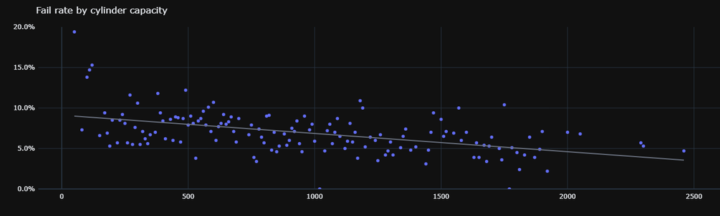

```python
fig = px.scatter(
    fail_rate_by_cc,
    y='fail_rate',
    x='cylinder_capacity',
    trendline="ols",
    title="Fail rate by cylinder capacity",
    hover_data={
        'cylinder_capacity': True,
        'test_num': True,
        'fail_rate': True
    }
)
fig.data[-1].line.color = '#6B7280'
fig.update_layout(
    yaxis=dict(
        title='',
        tickformat=".1%",
        range=[0, 0.2]
    ),
    xaxis=dict(title=''),
    # bargap=0.1,
    width=900,
    height=400,
    margin=dict(l=0, r=0, t=50, b=50, pad=5),
)
fig.show()
```

We see a tendency where higher cylinder capacity is the lower chance of failing the test. My guess is higher cylinder capacity is belong to more expensive motorcycles with high quality parts. We'll check do separate points on scatterplot belong to a certain brands.

```python
capacity_bins = pd.cut(
    first_test["cylinder_capacity"],
    bins=[40, 125, 250, 400, 500, 750, 1000, 1500, 2000, 2500],
    labels=["40–125","125–250","250–400","400–500","500–750",
            "750–1000","1000–1500","1500–2000","2000–2500"],
    include_lowest=True,
    right=True
)

top5_makers_vs_other_by_cc = (
    first_test.groupby(
        ['top5_make_or_other', capacity_bins],
        as_index=False,
        observed=False)['passed']
    .value_counts()
    .pivot_table(
        columns='passed',
        values='count',
        index=['top5_make_or_other', 'cylinder_capacity'],
        fill_value=0,
        observed=False)
    .astype('int')
)
top5_makers_vs_other_by_cc.columns.name = None
top5_makers_vs_other_by_cc = (
    top5_makers_vs_other_by_cc.reset_index()
    .rename(columns={True:'passed', False: 'failed'})
)
top5_makers_vs_other_by_cc['test_num'] = (
    top5_makers_vs_other_by_cc['failed'] + top5_makers_vs_other_by_cc['passed']
)
top5_makers_vs_other_by_cc['fail_rate'] = (
    (top5_makers_vs_other_by_cc['failed']
     / top5_makers_vs_other_by_cc['test_num']
    ).round(3)
)

top5_makers_vs_other_by_cc = (
    top5_makers_vs_other_by_cc.loc[
        top5_makers_vs_other_by_cc['test_num']>=30
        ]
)
```

```python
top5_makers_vs_other_by_cc
```

|  | top5_make_or_other | cylinder_capacity | failed | passed | test_num | fail_rate |
| --- | --- | --- | --- | --- | --- | --- |
| 0 | HONDA | 40–125 | 1166 | 8014 | 9180 | 0.127 |
| 1 | HONDA | 125–250 | 447 | 5748 | 6195 | 0.072 |
| 2 | HONDA | 250–400 | 443 | 6430 | 6873 | 0.064 |
| 3 | HONDA | 400–500 | 856 | 12218 | 13074 | 0.065 |
| 4 | HONDA | 500–750 | 3595 | 37171 | 40766 | 0.088 |
| 5 | HONDA | 750–1000 | 2327 | 31812 | 34139 | 0.068 |
| 6 | HONDA | 1000–1500 | 1155 | 14715 | 15870 | 0.073 |
| 7 | HONDA | 1500–2000 | 150 | 2482 | 2632 | 0.057 |
| 9 | KAWASAKI | 40–125 | 18 | 134 | 152 | 0.118 |
| 10 | KAWASAKI | 125–250 | 187 | 1487 | 1674 | 0.112 |
| 11 | KAWASAKI | 250–400 | 217 | 1973 | 2190 | 0.099 |
| 12 | KAWASAKI | 400–500 | 308 | 2174 | 2482 | 0.124 |
| 13 | KAWASAKI | 500–750 | 2373 | 23191 | 25564 | 0.093 |
| 14 | KAWASAKI | 750–1000 | 1051 | 14998 | 16049 | 0.065 |
| 15 | KAWASAKI | 1000–1500 | 958 | 16683 | 17641 | 0.054 |
| 16 | KAWASAKI | 1500–2000 | 40 | 491 | 531 | 0.075 |
| 17 | KAWASAKI | 2000–2500 | 5 | 69 | 74 | 0.068 |
| 18 | OTHER BRANDS | 40–125 | 880 | 3488 | 4368 | 0.201 |
| 19 | OTHER BRANDS | 125–250 | 599 | 6240 | 6839 | 0.088 |
| 20 | OTHER BRANDS | 250–400 | 1388 | 18506 | 19894 | 0.070 |
| 21 | OTHER BRANDS | 400–500 | 551 | 8050 | 8601 | 0.064 |
| 22 | OTHER BRANDS | 500–750 | 1499 | 19435 | 20934 | 0.072 |
| 23 | OTHER BRANDS | 750–1000 | 2852 | 48080 | 50932 | 0.056 |
| 24 | OTHER BRANDS | 1000–1500 | 3815 | 79114 | 82929 | 0.046 |
| 25 | OTHER BRANDS | 1500–2000 | 1071 | 21790 | 22861 | 0.047 |
| 26 | OTHER BRANDS | 2000–2500 | 0 | 34 | 34 | 0.000 |
| 27 | SUZUKI | 40–125 | 54 | 348 | 402 | 0.134 |
| 28 | SUZUKI | 125–250 | 160 | 1994 | 2154 | 0.074 |
| 29 | SUZUKI | 250–400 | 379 | 3588 | 3967 | 0.096 |
| 30 | SUZUKI | 400–500 | 149 | 1068 | 1217 | 0.122 |
| 31 | SUZUKI | 500–750 | 3451 | 32234 | 35685 | 0.097 |
| 32 | SUZUKI | 750–1000 | 933 | 12915 | 13848 | 0.067 |
| 33 | SUZUKI | 1000–1500 | 1176 | 16732 | 17908 | 0.066 |
| 34 | SUZUKI | 1500–2000 | 40 | 669 | 709 | 0.056 |
| 38 | TRIUMPH | 250–400 | 3 | 32 | 35 | 0.086 |
| 39 | TRIUMPH | 400–500 | 2 | 65 | 67 | 0.030 |
| 40 | TRIUMPH | 500–750 | 751 | 10506 | 11257 | 0.067 |
| 41 | TRIUMPH | 750–1000 | 2267 | 38055 | 40322 | 0.056 |
| 42 | TRIUMPH | 1000–1500 | 1600 | 24658 | 26258 | 0.061 |
| 43 | TRIUMPH | 1500–2000 | 148 | 1854 | 2002 | 0.074 |
| 44 | TRIUMPH | 2000–2500 | 145 | 2583 | 2728 | 0.053 |
| 45 | YAMAHA | 40–125 | 326 | 1527 | 1853 | 0.176 |
| 46 | YAMAHA | 125–250 | 289 | 3612 | 3901 | 0.074 |
| 47 | YAMAHA | 250–400 | 215 | 3307 | 3522 | 0.061 |
| 48 | YAMAHA | 400–500 | 101 | 1151 | 1252 | 0.081 |
| 49 | YAMAHA | 500–750 | 2777 | 29367 | 32144 | 0.086 |
| 50 | YAMAHA | 750–1000 | 1636 | 27811 | 29447 | 0.056 |
| 51 | YAMAHA | 1000–1500 | 833 | 11600 | 12433 | 0.067 |
| 52 | YAMAHA | 1500–2000 | 70 | 1252 | 1322 | 0.053 |

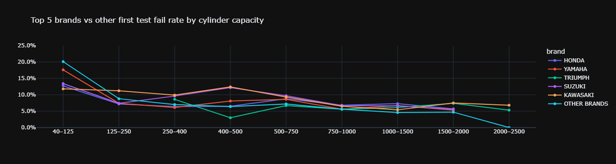

```python
fig = px.line(
    top5_makers_vs_other_by_cc,
    x='cylinder_capacity',
    y='fail_rate',
    color='top5_make_or_other',
    title='Top 5 brands vs other first test fail rate by cylinder capacity',
    markers=True,
    category_orders={
        "top5_make_or_other": ["HONDA", "YAMAHA", "TRIUMPH", "SUZUKI", "KAWASAKI", "OTHER BRANDS"]
    }
)
fig.update_layout(
    legend_title_text='brand',
    yaxis=dict(
        title='',
        tickformat=".1%",
        range=[0, 0.25]
    ),
    xaxis=dict(title=''),
    # bargap=0.1,
    # width=900,
    # height=400,
    # margin=dict(l=0, r=0, t=50, b=50, pad=5),
)
fig.show()
```

## Merging datasets for creating test details

To dive deeper, i would like to restructure `ig` table. The reason is `['item_id']` may refer to both single part and section. Next it will be merged with `itde` for futher analysis.

```python
moto_items = (
    ig[['test_item_id',
        'test_item_set_section_id',
        'item_name']]
    .merge(
         ig[['test_item_id', 'item_name']],
         how='left',
         suffixes=('', '_section'),
         left_on='test_item_set_section_id',
         right_on='test_item_id'
    )
    .drop(
         ['test_item_id_section'],
         axis=1
    )
    .rename(
        columns={
            'item_name_section': 'section_name'})
)
moto_items['section_name'] = (
    moto_items['section_name']
    .str.replace('motorcycle',
                 '',
                 case=False,
                 regex=True)
    .str.strip()
    .str.lower()
    .str.capitalize()
)
moto_items_itde = (
    itde.merge(
        moto_items,
        on=['test_item_id',
            'test_item_set_section_id'])
        .rename(
            columns={
                'test_item_id': 'item_id',
                'test_item_set_section_id': 'section_id'}
        )
)
moto_items_itde.head()
```

|  | rfr_id | item_id | minor_item | rfr_deficiency_category | rfr_desc | section_id | item_name | section_name |
| --- | --- | --- | --- | --- | --- | --- | --- | --- |
| 0 | 4 | 3 | True | Pre-EU Directive | an obligatory lamp missing | 1 | Motorcycle front | Lighting and signalling |
| 1 | 5 | 3 | True | Pre-EU Directive | so damaged or deteriorated that its function i... | 1 | Motorcycle front | Lighting and signalling |
| 2 | 6 | 3 | True | Pre-EU Directive | so damaged or deteriorated that its function i... | 1 | Motorcycle front | Lighting and signalling |
| 3 | 7 | 3 | True | Pre-EU Directive | an insecure lamp | 1 | Motorcycle front | Lighting and signalling |
| 4 | 8 | 3 | True | Pre-EU Directive | is obscured or does not face the front or rear... | 1 | Motorcycle front | Lighting and signalling |

```python
display(
    Markdown(
        f"Unique motorcycle parts: "
        f"{(moto_items_itde['section_name']
        +  '-' + moto_items_itde['item_name']).nunique()}"
    )
)
display(
    Markdown(
        f"Unique motorcycle sections: "
        f"{moto_items_itde['section_id'].nunique()}"
    )
)
display(
    Markdown(
        f"Unique reason for rejection(rfr): "
        f"{moto_items_itde['rfr_id'].nunique()}"
    )
)
```

Unique motorcycle parts: 198

Unique motorcycle sections: 22

Unique reason for rejection(rfr): 1389

```python
display(Markdown(f"Each unique reason for rejection(rfr) refers to:"))
moto_items_itde['rfr_deficiency_category'].value_counts()
```

Each unique reason for rejection(rfr) refers to:

```
rfr_deficiency_category
Pre-EU Directive    750
Major               398
Dangerous           179
Minor                62
Name: count, dtype: int64
```

If item belongs to "Dangerous" or "Major" category and fails, it will lead to failed test

```python
display(Markdown(f"Rfrs in 'Dangerous' & 'Major' categories grouped by"))
(moto_items_itde.loc[
    moto_items_itde['rfr_deficiency_category'].isin(['Dangerous', 'Major'])]
    .groupby('section_name')
    .size()
    .sort_values(ascending=False)
)
```

Rfrs in 'Dangerous' & 'Major' categories grouped by

```
section_name
Brakes                           169
Suspension                       103
Structure and attachments         96
Lamps and reflectors              76
Steering                          64
Wheels                            30
Tyres                             22
Identification of the vehicle     11
Audible warning (horn)             4
Items not tested                   2
dtype: int64
```

```python
display(
    Markdown(
        f"Is moto part considered as 'minor' "
        f"(qualifies for free partial retest)."
    )
)
(moto_items_itde.loc[
    moto_items_itde['rfr_deficiency_category'].isin(['Dangerous', 'Major'])]
    ['minor_item']
    .value_counts()
)
```

Is moto part considered as 'minor' (qualifies for free partial retest).

```
minor_item
True     532
False     45
Name: count, dtype: int64
```

```python
display(
    Markdown(
        f"Number of moto parts by sections in 'Pre-EU Directive' "
        f"& 'Minor' categories (will not lead to test failure)"
    )
)
(moto_items_itde.loc[
    ~moto_items_itde['rfr_deficiency_category'].isin(['Dangerous', 'Major'])]
    .groupby('section_name')
    .size()
    .sort_values(ascending=False)
)
```

Number of moto parts by sections in 'Pre-EU Directive' & 'Minor' categories (will not lead to test failure)

```
section_name
Lighting and signalling      185
Brakes                       175
Steering and suspension      112
Sidecar                      109
Tyres and wheels              53
Lamps and reflectors          39
Reg plates and vin            37
Non-component advisories      22
Fuel and exhaust              20
Drive system                  19
Body and structure            17
Audible warning (horn)         9
Driving controls               5
Items not tested               3
Suspension                     3
Structure and attachments      2
Performance                    1
Steering                       1
dtype: int64
```

# 4. Detailed analysis

## Brief summary

Now we'll merge all tables to have detailed analysis of test results

```python
test_details = ti.merge(moto_items_itde, on='rfr_id', how='left')
test_details.head()
```

|  | test_id | rfr_id | rfr_type_code | mot_test_rfr_location_type_id | completed_date | item_id | minor_item | rfr_deficiency_category | rfr_desc | section_id | item_name | section_name |
| --- | --- | --- | --- | --- | --- | --- | --- | --- | --- | --- | --- | --- |
| 0 | 939637859 | 40098 | A | 9 | 2024-01-02 10:03:29 | 25016 | True | Dangerous | Brake lining or pad worn below 1.0mm | 25003 | Brake pads | Brakes |
| 1 | 401677457 | 40450 | A | 25 | 2024-01-02 10:47:37 | 25085 | True | Major | A shock absorber not functioning or leaking se... | 25081 | Shock absorbers | Suspension |
| 2 | 401677457 | 40546 | A | 83 | 2024-01-02 10:47:37 | 25108 | True | Major | Exhaust system leaking or insecure | 25105 | Exhaust system | Structure and attachments |
| 3 | 401677457 | 40663 | A | 5 | 2024-01-02 10:47:37 | 25108 | False | Major | Exhaust noise levels in excess of those permitted | 25105 | Exhaust system | Structure and attachments |
| 4 | 401677457 | 40547 | A | 5 | 2024-01-02 10:47:37 | 25108 | True | Major | Exhaust system leaking or insecure | 25105 | Exhaust system | Structure and attachments |

```python
first_test_details = (
    first_test.merge(
        test_details,
        on=['test_id', 'completed_date'],
        how='inner')
    .drop(['test_id', 'test_type'],
          axis=1)
)
first_test_details.head()
```

|  | vehicle_id | test_result | test_mileage | postcode_area | make | model | cylinder_capacity | first_use_date | completed_date | age | ... | rfr_id | rfr_type_code | mot_test_rfr_location_type_id | item_id | minor_item | rfr_deficiency_category | rfr_desc | section_id | item_name | section_name |
| --- | --- | --- | --- | --- | --- | --- | --- | --- | --- | --- | --- | --- | --- | --- | --- | --- | --- | --- | --- | --- | --- |
| 0 | 73 | P | 29024 | SA | HONDA | UNCLASSIFIED | 249 | 1991-03-22 | 2024-07-13 10:54:40 | 33.311431 | ... | 10013 | A | 1 | 10000 | True | Pre-EU Directive | <NA> | 10000 | Non-component advisories | Non-component advisories |
| 1 | 73 | P | 29024 | SA | HONDA | UNCLASSIFIED | 249 | 1991-03-22 | 2024-07-13 10:54:40 | 33.311431 | ... | 40391 | A | 9 | 25101 | True | Major | A wheel hub excessively worn or damaged | 25098 | Hub | Wheels |
| 2 | 782 | P | 17755 | B | HONDA | CBR1100X-2 | 1137 | 2003-06-04 | 2024-07-25 13:10:18 | 21.141684 | ... | 40450 | A | 25 | 25085 | True | Major | A shock absorber not functioning or leaking se... | 25081 | Shock absorbers | Suspension |
| 3 | 13284 | PRS | 33733 | LE | YAMAHA | FZS600 | 599 | 1999-11-24 | 2024-07-15 12:02:36 | 24.640657 | ... | 40669 | PRS | 1 | 25072 | False | Dangerous | A stop lamp(s) does not illuminate by the oper... | 25061 | Stop lamp | Lamps and reflectors |
| 4 | 20755 | F | 4659 | AL | KAWASAKI | ZX | 599 | 2014-07-01 | 2024-08-14 08:14:46 | 10.121834 | ... | 40323 | F | 9 | 25072 | True | Major | Stop lamp missing, inoperative or in the case ... | 25061 | Stop lamp | Lamps and reflectors |

5 rows × 23 columns

```python
# выяснить что такое ABRVE , если что добавить в ABR
```

```python
first_test_moto_num = first_test['vehicle_id'].nunique()
test_result_values = first_test['test_result'].value_counts()
motos_passed_flawlessly = (
    first_test_moto_num-first_test_details["vehicle_id"].nunique()
)
motos_passed_minor_defects = test_result_values["P"] - motos_passed_flawlessly
motos_passed_prs = test_result_values["PRS"]
motos_failed = test_result_values["F"]
motos_aborted = test_result_values["ABR"]
motos_abandoned = test_result_values["ABA"]

data = {
    "moto_num": [
        motos_passed_flawlessly,
        motos_passed_minor_defects,
        motos_passed_prs,
        motos_failed,
        motos_aborted,
        motos_abandoned
    ]
}

index = [
    "motos passed test flawlessly",
    "motos passed test with minor defects",
    "motos passed test after PRS",
    "motos failed test",
    "motos aborted test",
    "motos abandoned test"
]

first_test_stats = pd.DataFrame(data, index=index)
first_test_stats["percentage(%)"] = (
    (first_test_stats["moto_num"] / first_test_stats['moto_num'].sum() * 100)
    .round(2)
)
first_test_stats.loc[first_test_stats.shape[0]+1] = (
    first_test_stats.sum(axis=0).round()
)
first_test_stats = first_test_stats.rename(index={7: 'Total'})
first_test_stats['moto_num'] = first_test_stats['moto_num'].astype('Int32')
display(Markdown(f"Results of the first test:"))
first_test_stats
```

Results of the first test:

|  | moto_num | percentage(%) |
| --- | --- | --- |
| motos passed test flawlessly | 446806 | 67.94 |
| motos passed test with minor defects | 132413 | 20.13 |
| motos passed test after PRS | 32933 | 5.01 |
| motos failed test | 43889 | 6.67 |
| motos aborted test | 1477 | 0.22 |
| motos abandoned test | 145 | 0.02 |
| Total | 657663 | 100.00 |

Now we'll depict detailed picture of first test result, using `['rfr_deficiency_category']`, i.e how many moto parts were into various rfr categories. It means, we won't count motos passed the test flawlessly.

```python
first_test_res_pivot = (first_test_details.pivot_table(
    index=['rfr_deficiency_category', 'rfr_type_code'],
    columns='passed',
    values='vehicle_id',
    aggfunc='size',
    fill_value=0,
    observed=True)
)
first_test_res_pivot['failed_pct(%)'] =  (
    (first_test_res_pivot[False] / first_test_res_pivot[False].sum() * 100)
    .round(3)
)
first_test_res_pivot['passed_pct(%)'] =  (
    (first_test_res_pivot[True] / first_test_res_pivot[True].sum() * 100).round(3)
)
first_test_res_pivot['passed_moto_mean'] = (
    (first_test_res_pivot[True]
    / first_test_details.loc[
        first_test_details['passed']==True,
        'vehicle_id']
        .nunique()
    )
    .round(2)
)
first_test_res_pivot['failed_moto_mean'] = (
    (first_test_res_pivot[False]
     / first_test_details.loc[
         first_test_details['passed']==False,
         'vehicle_id']
         .nunique()
    )
    .round(2)
)

grand = first_test_res_pivot.sum(axis=0).to_frame().T
grand.index = pd.MultiIndex.from_tuples([('All', 'All')])
first_test_res_pivot = (
    pd.concat([first_test_res_pivot,
               grand]
             )
    .rename(columns={True: 'passed',
                     False: 'failed'}
           )
)
first_test_res_pivot = (
    first_test_res_pivot[
        [
            'passed', 'passed_moto_mean', 'passed_pct(%)',
            'failed', 'failed_moto_mean',  'failed_pct(%)'
        ]
    ]
)
first_test_res_pivot[['passed', 'failed']] = (
    first_test_res_pivot[['passed', 'failed']].astype('Int32')
)
first_test_res_pivot.columns.name = None
first_test_res_pivot
```

|  |  | passed | passed_moto_mean | passed_pct(%) | failed | failed_moto_mean | failed_pct(%) |
| --- | --- | --- | --- | --- | --- | --- | --- |
| Dangerous | A | 71474 | 0.43 | 26.859 | 11991 | 0.27 | 9.081 |
|  | F | 0 | 0.00 | 0.000 | 20621 | 0.47 | 15.616 |
|  | PRS | 5841 | 0.03 | 2.195 | 116 | 0.00 | 0.088 |
| Major | A | 145534 | 0.87 | 54.690 | 28341 | 0.65 | 21.463 |
|  | F | 0 | 0.00 | 0.000 | 66262 | 1.51 | 50.180 |
|  | PRS | 33396 | 0.20 | 12.550 | 1035 | 0.02 | 0.784 |
| Minor | A | 52 | 0.00 | 0.020 | 7 | 0.00 | 0.005 |
|  | M | 7090 | 0.04 | 2.664 | 2860 | 0.07 | 2.166 |
| Pre-EU Directive | A | 2719 | 0.02 | 1.022 | 815 | 0.02 | 0.617 |
| All | All | 266106 | 1.59 | 100.000 | 132048 | 3.01 | 100.000 |

As we have unambiguous rules for passed / failed tests, we see motos that failed the test have parts with mark "F" in "Dangerous" and "Major" category in `['failed']` column, meanwhile motos that passed the test have more count for mark "A", meaning their condition was good enough not to fail the test. In average each failed moto has almost 2 defect parts. And despite of no explanation for severity in guide between categories "Dangerous" & "Major" in index (`['rfr_deficiency_category']`), looking on numbers we can say that "Dangerous" has more severity as number of vehicle is less for this category. ПОГУГЛИТЬ РАЗНИЦУ МЕЖДУ КАТЕГОРИЯМИ / ПОДУМАТЬ НАСЧЕТ ДЕТАЛЬНОГО ОПИСАНИЯ ПРИЧИН ДЛЯ ОТКАЗА (СРАВНЕНИЯ ПРИЧИН DANGEROUS И MAJOR)

Now we'll group results of the first test by various columns to create treemap to highlight existing hierarchies and analyze distribution in branches and nodes.

```python
rfr_num_by_type_section_item = (
    first_test_details.groupby(
        [
            'rfr_type_code',
            'section_name',
            'item_name',
            'rfr_desc'
        ],
        observed=True,
        as_index=False)
    .size()
    .sort_values(
        by='size',
        ascending=False)
)
rfr_num_by_type_section_item['rfr_type_code'] = rfr_num_by_type_section_item['rfr_type_code'].astype(str)

rfr_num_by_type_section_item['rfr_type_pct'] = (
    rfr_num_by_type_section_item.groupby('rfr_type_code')['size'].transform('sum')
    / rfr_num_by_type_section_item['size'].sum()
).round(4)

rfr_num_by_type_section_item['section_pct_by_rfr_type'] = (
    rfr_num_by_type_section_item.groupby(
            ['rfr_type_code', 'section_name']
        )
        ['size']
        .transform('sum')
    / rfr_num_by_type_section_item.groupby('rfr_type_code')['size'].transform('sum')
).round(4)

rfr_num_by_type_section_item['rfr_pct_by_section'] = (
    rfr_num_by_type_section_item.groupby(
            ['rfr_type_code', 'section_name', 'rfr_desc']
        )
        ['size']
        .transform('sum')

        / rfr_num_by_type_section_item.groupby(
            ['rfr_type_code', 'section_name']
        )
        ['size']
        .transform('sum')
).round(4)

rfr_num_by_type_section_item['rfr_pct_by_rfr_type'] = (
    rfr_num_by_type_section_item.groupby(
            ['rfr_desc']
        )
        ['size']
        .transform('sum')

        / rfr_num_by_type_section_item.groupby(
            ['rfr_type_code']
        )
        ['size']
        .transform('sum')
).round(4)
```

```python
rfr_num_by_type_section_item
```

|  | rfr_type_code | section_name | item_name | rfr_desc | size | rfr_type_pct | section_pct_by_rfr_type | rfr_pct_by_section | rfr_pct_by_rfr_type |
| --- | --- | --- | --- | --- | --- | --- | --- | --- | --- |
| 115 | A | Tyres | Condition | Tyre tread depth not in accordance with the re... | 47822 | 0.6523 | 0.1979 | 0.9387 | 0.2142 |
| 84 | A | Structure and attachments | Exhaust system | Exhaust noise levels in excess of those permitted | 44332 | 0.6523 | 0.2993 | 0.5755 | 0.1762 |
| 13 | A | Brakes | Brake pads | Brake lining or pad worn below 1.0mm | 24128 | 0.6523 | 0.2937 | 0.3230 | 0.1144 |
| 82 | A | Structure and attachments | Drive chain | A transmission belt, chain, sprocket or pulley... | 20852 | 0.6523 | 0.2993 | 0.2755 | 0.0942 |
| 46 | A | Brakes | Roller brake test | Excessive fluctuation in brake effort through ... | 19008 | 0.6523 | 0.2937 | 0.2528 | 0.0835 |
| ... | ... | ... | ... | ... | ... | ... | ... | ... | ... |
| 591 | PRS | Steering | Handlebars | Handlebar grip missing | 1 | 0.1023 | 0.0320 | 0.0008 | 0.0001 |
| 584 | PRS | Steering | Fork yoke | Forks or fork yoke in such a condition that st... | 1 | 0.1023 | 0.0320 | 0.0015 | 0.0011 |
| 306 | F | Steering | Linkage | A steering linkage component fractured or defo... | 1 | 0.2202 | 0.0493 | 0.0002 | 0.0001 |
| 315 | F | Steering | Sidecar wheel alignment | Toe-out of the sidecar wheel relative to the m... | 1 | 0.2202 | 0.0493 | 0.0002 | 0.0000 |
| 689 | PRS | Wheels | Condition | Any fracture or welding defect on a wheel | 1 | 0.1023 | 0.0103 | 0.0024 | 0.0003 |

690 rows × 9 columns

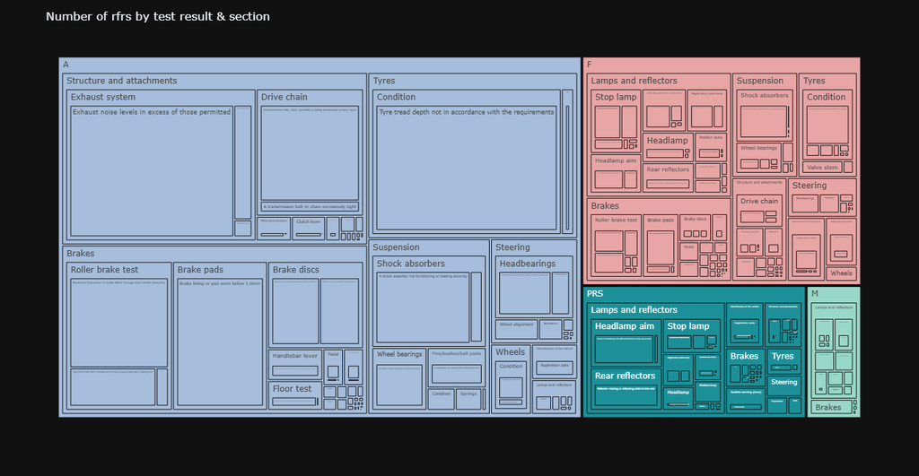

```python
fig = px.treemap(
    rfr_num_by_type_section_item,
    path=['rfr_type_code',
          'section_name',
          'item_name',
          'rfr_desc'],
    values='size',
    color='rfr_type_code',
    color_discrete_map={
        "A": "#a6bddb",
        "F":  "#E8A5A5",
        "PRS": "#1c9099",
        "M": "#99d8c9"
    },
    hover_data={
        'size': True,
        'rfr_type_pct':True,
        'section_pct_by_rfr_type':True,
        'rfr_pct_by_section': True,
        'rfr_pct_by_rfr_type': True
    }
)
fig.update_layout(
    width=1100,
    height=700,
    title='Number of rfrs by test result & section'
)
fig.update_traces(
    hovertemplate=
        "<b>%{label}</b><br>" +
        "Size: %{customdata[0]}<br>" +
        "Rfr type percentage: %{customdata[1]:.2%}<br>" +
        "Section percentage by rfr type: %{customdata[2]:.2%}<br>" +
        "Rfr percentage by section: %{customdata[3]:.2%}<br>" +
        "Rfr percentage by rfr type: %{customdata[4]:.2%}<br>" +
        "<extra></extra>"
)
# Добавлять ли item
```

```python
first_test_failed = first_test_details.loc[
    first_test_details['test_result']=='F'
    ]
# раньше moto_failed_items
first_test_failed_items = first_test_failed.loc[
    first_test_failed['rfr_type_code']=='F'
    ]
```

```python
rfr_num_by_section = (
    first_test_failed_items['section_name'].value_counts()
    .reset_index()
)
rfr_num_by_section['pct'] = (
    rfr_num_by_section['count'] / rfr_num_by_section['count'].sum()
)
rfr_num_by_section['cumsum_pct'] = rfr_num_by_section['pct'].cumsum()
# rfr_num_by_section.head()
# добавить % к столбцам
```

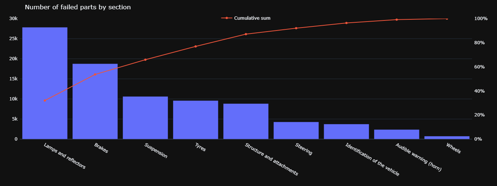

```python
fig = px.bar(
    rfr_num_by_section,
    x="section_name",
    y="count",
    title="Number of failed parts by section",
    hover_data={'count': ':.0f'}
)

fig.add_trace(
    go.Scatter(
        x=rfr_num_by_section["section_name"],
        y=rfr_num_by_section["cumsum_pct"],
        mode="lines+markers",
        name="Cumulative sum",
        yaxis="y2",
        hovertemplate="Category: %{x}<br>Cumulative sum: %{y:.2%}<extra></extra>"
    )
)

fig.update_layout(
    yaxis=dict(
        title="",
        range=[0,30000]
    ),
    yaxis2=dict(
        title="",
        showgrid=False,
        overlaying="y",
        side="right",
        range=[0, 1],
        tickformat=".0%"
    ),
    xaxis=dict(
        title="",
        showticklabels=True,
        tickfont=dict(size=12)
        ),
    bargap=0.1,
    width=1200,
    height=500,
    margin=dict(l=10, r=50, t=50, b=0, pad=5),
    legend=dict(
        orientation="h",
        yanchor="top",
        y=1.05,
        xanchor="center",
        x=0.5
    ),
)

fig.show()
```

```python
rfr_per_moto = (
    first_test_failed_items.groupby('vehicle_id')['rfr_id'].agg(rfr_num='count')
)
failed_parts_num_by_moto_count = (
    rfr_per_moto['rfr_num'].value_counts()
    .sort_index()
    .reset_index()
    .loc[lambda x: x['count']>= 29]
)
```

```python
# for rfr_num in range(1,failed_parts_num_by_moto_count['rfr_num'].max()+1):
#     try:
#         moto_ids = rfr_per_moto[rfr_per_moto['rfr_num'] == rfr_num].index
#         moto = (
#             tr.loc[tr['vehicle_id'].isin(moto_ids)]
#             .sort_values(by=['vehicle_id', 'completed_date'])
#             .groupby('vehicle_id', as_index=False).last()
#         )
#         # failed_parts_num_by_moto_count['pct'] = failed_parts_num_by_moto_count.loc[failed_parts_num_by_moto_count['rfr_num']==rfr_num] = (moto['passed'].value_counts(normalize=True)[True]*100).round(2)
#     # print(moto['passed'].value_counts(normalize=True)*100)
#         print(f'Motos eventually passed the test with {rfr_num} defects: '
#             f'{(moto['passed'].value_counts(normalize=True)[True]*100).round(2)}%')
#     except:
#         continue
```

```python
failed_parts_num_by_moto_count['pass_ratio'] = 0.0
for rfr_num in range(1,failed_parts_num_by_moto_count['rfr_num'].max()+1):
    try:
        moto_ids = rfr_per_moto[rfr_per_moto['rfr_num'] == rfr_num].index
        moto = (
            tr.loc[tr['vehicle_id'].isin(moto_ids)]
            .sort_values(by=['vehicle_id', 'completed_date'])
            .groupby('vehicle_id', as_index=False).last()
        )
        pct = (moto['passed'].value_counts(normalize=True)[True]).round(2)
        failed_parts_num_by_moto_count.at[rfr_num-1, 'pass_ratio'] = pct

    except Exception as e:
        continue
```

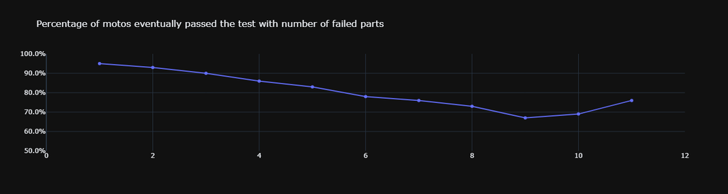

```python
fig = px.line(
    failed_parts_num_by_moto_count,
    x='rfr_num',
    y='pass_ratio',
    title='Percentage of motos eventually passed the test with number of failed parts',
    markers=True,
    hover_data={'count': True}

)
fig.update_layout(
    yaxis=dict(
        title='',
        tickformat=".1%",
        range=[0.5, 1]
    ),
    xaxis=dict(
        title='',
        tick0=1,
        range=[0,12]
    ),
)
fig.show()
```

```python
# # пересчитать еще раз
# for rfr_num in range(1,failed_parts_num_by_moto_count.index.max()+1):
#     try:
#         moto_ids = rfr_per_moto[rfr_per_moto['rfr_num'] == rfr_num].index
#         moto = (
#             tr.loc[tr['vehicle_id'].isin(moto_ids)]
#             .sort_values(by=['vehicle_id', 'completed_date'])
#             .groupby('vehicle_id', as_index=False).last()
#         )
#     # print(moto['passed'].value_counts(normalize=True)*100)
#         print(f'Motos eventually passed the test with {rfr_num} defects: '
#             f'{(moto['passed'].value_counts(normalize=True)[True]*100).round(2)}%')
#     except:
#         continue
```

### Comparison rfrs for motos which failed first test and didn't take the second vs took second test after first failure

Despite amount of motos which didn't take second test is relatively small (3.2k) we would analyze their rfrs creating ranks and comparing their size to find out severe defects that caused dropping the second attempt.

```python
moto_failed_first_test_vals = (
    first_test.loc[first_test['passed']==False, 'vehicle_id']
    .values
)
second_test_moto_vals = (
    tr.sort_values(by=['vehicle_id', 'completed_date'])
    .groupby('vehicle_id')
    .nth(1)
    ['vehicle_id']
    .values
)
moto_abandonded_second_test = (
    tr.loc[
        (tr['vehicle_id'].isin(moto_failed_first_test_vals))
        & (~tr['vehicle_id'].isin(second_test_moto_vals))
    ]
)
moto_abandonded_second_test_details = (
    moto_abandonded_second_test.merge(
        test_details, on=['test_id', 'completed_date'], how='left')
    .drop(['test_id', 'test_type'], axis=1)
.loc[lambda x: x['rfr_type_code']=='F']
)
moto_abandonded_second_test_reasons = (
    moto_abandonded_second_test_details.groupby(
        ['rfr_deficiency_category', 'section_name',
         'item_name', 'rfr_desc'],
        as_index=False,
        observed=True
    )
    .size()
    .sort_values(by=['size'], ascending=[False])
    .reset_index(drop=True)
)
display(Markdown(f"Rfrs of motos failed first test and didn't take the second:"))
moto_abandonded_second_test_reasons.head(10)
```

Rfrs of motos failed first test and didn't take the second:

|  | rfr_deficiency_category | section_name | item_name | rfr_desc | size |
| --- | --- | --- | --- | --- | --- |
| 0 | Major | Suspension | Shock absorbers | A shock absorber not functioning or leaking se... | 997 |
| 1 | Dangerous | Tyres | Condition | Tyre tread depth not in accordance with the re... | 434 |
| 2 | Major | Brakes | Roller brake test | Significant brake effort recorded with no brak... | 302 |
| 3 | Major | Brakes | Roller brake test | Excessive fluctuation in brake effort through ... | 268 |
| 4 | Dangerous | Brakes | Brake pads | Brake lining or pad worn below 1.0mm | 266 |
| 5 | Major | Lamps and reflectors | Stop lamp | Stop lamp missing, inoperative or in the case ... | 262 |
| 6 | Major | Lamps and reflectors | Rear reflectors | Reflector missing or reflecting white to the rear | 261 |
| 7 | Major | Lamps and reflectors | Individual direction indicators | A direction indicator lamp missing, inoperativ... | 237 |
| 8 | Major | Lamps and reflectors | Headlamp aim | The aim of a headlamp is not within limits lai... | 236 |
| 9 | Major | Structure and attachments | Drive chain | A transmission belt, chain, sprocket or pulley... | 226 |

```python
moto_having_second_test_first_test_res = (
    tr.loc[tr['vehicle_id'].isin(second_test_moto_vals)]
    .sort_values(by=['vehicle_id', 'completed_date'])
    .groupby('vehicle_id')
    .nth(0)
)
moto_having_second_test_first_test_details = (
    moto_having_second_test_first_test_res.merge(
        test_details,
        on=['test_id', 'completed_date'],
        how='left'
    )
    .drop(['test_id', 'test_type'], axis=1)
    .loc[lambda x: x['rfr_type_code']=='F']
)
moto_having_second_test_first_test_reasons = (
    moto_having_second_test_first_test_details.groupby(
        ['rfr_deficiency_category', 'section_name',
        'item_name', 'rfr_desc'],
        as_index=False,
        observed=True
    )
    .size()
    .sort_values(by=['size'], ascending=[False])
    .reset_index(drop=True)
)
display(Markdown(f"Rfrs of motos failed first test and took the second:"))
moto_having_second_test_first_test_reasons.head(10)
```

Rfrs of motos failed first test and took the second:

|  | rfr_deficiency_category | section_name | item_name | rfr_desc | size |
| --- | --- | --- | --- | --- | --- |
| 0 | Dangerous | Tyres | Condition | Tyre tread depth not in accordance with the re... | 5808 |
| 1 | Major | Suspension | Shock absorbers | A shock absorber not functioning or leaking se... | 5423 |
| 2 | Dangerous | Brakes | Brake pads | Brake lining or pad worn below 1.0mm | 3844 |
| 3 | Major | Identification of the vehicle | Registration plate | Number plate does not conform to the specified... | 2981 |
| 4 | Major | Lamps and reflectors | Rear reflectors | Reflector missing or reflecting white to the rear | 2833 |
| 5 | Major | Lamps and reflectors | Stop lamp | Stop lamp missing, inoperative or in the case ... | 2767 |
| 6 | Major | Lamps and reflectors | Headlamp | A headlamp missing, inoperative or more than ½... | 2481 |
| 7 | Major | Lamps and reflectors | Headlamp aim | The aim of a headlamp is not within limits lai... | 2442 |
| 8 | Major | Lamps and reflectors | Individual direction indicators | A direction indicator lamp missing, inoperativ... | 2293 |
| 9 | Major | Lamps and reflectors | Registration plate lamp | A rear registration plate lamp or light source... | 2195 |

```python
continued_vs_abandoned = (
    moto_abandonded_second_test_reasons.merge(
        moto_having_second_test_first_test_reasons,
        how='left',
        on=['rfr_deficiency_category', 'section_name', 'item_name', 'rfr_desc'],
        suffixes=('_abandoned', '_continued'))
    .head(50)
)
continued_vs_abandoned["rank_abandoned"] = (
    continued_vs_abandoned["size_abandoned"].rank(method="min", ascending=False)
)
continued_vs_abandoned["rank_continued"] = (
    continued_vs_abandoned["size_continued"].rank(method="min", ascending=False)
)
continued_vs_abandoned["size_diff"] = (
    continued_vs_abandoned["size_abandoned"]
    / continued_vs_abandoned["size_continued"]
)
continued_vs_abandoned["rank_diff"] = (
    continued_vs_abandoned["rank_continued"]
    - continued_vs_abandoned["rank_abandoned"]
)
continued_vs_abandoned = (
    continued_vs_abandoned.sort_values(by='rank_diff', ascending=False)
    .reset_index(drop=True)
)
continued_vs_abandoned.index = continued_vs_abandoned.index + 1
continued_vs_abandoned.head(20)
```

|  | rfr_deficiency_category | section_name | item_name | rfr_desc | size_abandoned | size_continued | rank_abandoned | rank_continued | size_diff | rank_diff |
| --- | --- | --- | --- | --- | --- | --- | --- | --- | --- | --- |
| 1 | Major | Structure and attachments | Exhaust system | Exhaust system leaking or insecure | 153 | 561 | 17.0 | 33.0 | 0.272727 | 16.0 |
| 2 | Major | Suspension | Pins/bushes/ball joints | A suspension pin, bush or joint excessively worn | 89 | 402 | 29.0 | 44.0 | 0.221393 | 15.0 |
| 3 | Major | Brakes | Brake discs | Brake disc or drum significantly and obviously... | 95 | 536 | 26.0 | 35.0 | 0.177239 | 9.0 |
| 4 | Major | Brakes | Brake discs | Contaminated with oil, grease etc | 110 | 631 | 24.0 | 32.0 | 0.174326 | 8.0 |
| 5 | Major | Brakes | Roller brake test | Significant brake effort recorded with no brak... | 302 | 2171 | 3.0 | 11.0 | 0.139106 | 8.0 |
| 6 | Major | Brakes | Roller brake test | Excessive fluctuation in brake effort through ... | 268 | 2087 | 4.0 | 12.0 | 0.128414 | 8.0 |
| 7 | Major | Brakes | Floor test | Significant brake effort recorded with no brak... | 116 | 754 | 22.0 | 29.0 | 0.153846 | 7.0 |
| 8 | Major | Brakes | Brake pads | A brake lining or pad contaminated with oil, g... | 106 | 657 | 25.0 | 31.0 | 0.161339 | 6.0 |
| 9 | Major | Steering | Wheel alignment | Wheels of a solo motorcycle sufficiently misal... | 56 | 254 | 41.0 | 47.0 | 0.220472 | 6.0 |
| 10 | Dangerous | Brakes | Brake discs | Brake disc or drum excessively weakened, insec... | 80 | 502 | 33.0 | 38.0 | 0.159363 | 5.0 |
| 11 | Major | Structure and attachments | Throttle | A throttle control not functioning correctly | 60 | 436 | 38.0 | 43.0 | 0.137615 | 5.0 |
| 12 | Dangerous | Structure and attachments | Drive chain | A transmission belt, chain, sprocket or pulley... | 75 | 494 | 35.0 | 39.0 | 0.151822 | 4.0 |
| 13 | Major | Steering | Headbearings | Steering head bearings excessively stiff, notc... | 169 | 1187 | 15.0 | 19.0 | 0.142376 | 4.0 |
| 14 | Dangerous | Structure and attachments | Riders seat | A rider’s seat missing or insecure | 49 | 239 | 44.0 | 48.0 | 0.205021 | 4.0 |
| 15 | Major | Wheels | Condition | A wheel excessively corroded, damaged or disto... | 40 | 153 | 46.0 | 50.0 | 0.261438 | 4.0 |
| 16 | Major | Structure and attachments | Drive chain | A transmission belt, chain, sprocket or pulley... | 226 | 2044 | 10.0 | 13.0 | 0.110568 | 3.0 |
| 17 | Major | Steering | Headbearings | Steering head bearings have excessive wear or ... | 58 | 447 | 39.0 | 42.0 | 0.129754 | 3.0 |
| 18 | Dangerous | Tyres | Condition | A tyre with a lump, bulge or tear caused by se... | 77 | 528 | 34.0 | 36.0 | 0.145833 | 2.0 |
| 19 | Major | Structure and attachments | Exhaust system | Exhaust noise levels in excess of those permitted | 95 | 761 | 26.0 | 28.0 | 0.124836 | 2.0 |
| 20 | Major | Suspension | Shock absorbers | A shock absorber bush excessively worn | 38 | 165 | 48.0 | 49.0 | 0.230303 | 1.0 |

```python
#переместить куда-то вверх
```

### Hard-to-repair motorcycle parts

Let's check the vehicle parts that failed the test again, i.e weren't fixed after first test

```python
second_test_details = (
    tr.groupby('vehicle_id')
    .nth(1)
    .merge(test_details, on=['test_id', 'completed_date'], how='inner')
    .drop(['test_id', 'test_type'], axis=1)
)

# сделать полностью читаемую строку
# посмотреть рейтинг провалившихся деталей в первом тесте и сравнитт
display(Markdown(f"Hard fixeble items"))
hard_fixable_items = (
    second_test_details.loc[second_test_details['rfr_type_code']=='F']
    .merge(
        first_test_details,
        on=['vehicle_id', 'rfr_type_code', 'item_id', 'section_id'],
        how='inner',
        suffixes=('_first', '_second')
    )
    .rename(
        columns={'section_name_first': 'section_name',
                 'item_name_first': 'item_name',
                 'rfr_desc_first': 'rfr_desc'}
    )
    .groupby(
        ['section_name', 'item_name', 'rfr_desc'],
        as_index=False)
    .size()
    .sort_values(by='size', ascending=False)
)
with pd.option_context('display.max_colwidth', None):
    display(hard_fixable_items.head(20))
```

Hard fixeble items

|  | section_name | item_name | rfr_desc | size |
| --- | --- | --- | --- | --- |
| 89 | Suspension | Shock absorbers | A shock absorber not functioning or leaking severely | 88 |
| 32 | Brakes | Roller brake test | Significant brake effort recorded with no brake applied indicating a binding brake | 69 |
| 29 | Brakes | Roller brake test | Excessive fluctuation in brake effort through each wheel revolution | 64 |
| 43 | Lamps and reflectors | Headlamp aim | The aim of a headlamp is not within limits laid down in the requirements | 43 |
| 12 | Brakes | Brake pads | Brake lining or pad worn below 1.0mm | 31 |
| 98 | Tyres | Condition | Tyre tread depth not in accordance with the requirements | 30 |
| 42 | Lamps and reflectors | Headlamp aim | Projected beam image is obviously incorrect | 22 |
| 33 | Identification of the vehicle | Registration plate | Number plate does not conform to the specified requirements | 21 |
| 92 | Suspension | Wheel bearings | A wheel bearing with excessive play | 20 |
| 39 | Lamps and reflectors | Headlamp | A headlamp missing, inoperative or more than ½ not functioning in the case of LED | 19 |
| 49 | Lamps and reflectors | Registration plate lamp | A rear registration plate lamp or light source missing or inoperative in the case of a single lamp or all lamps | 19 |
| 0 | Audible warning (horn) | Motorcycle audible warning (Horn) | Audible warning not working | 18 |
| 10 | Brakes | Brake pads | A brake lining or pad contaminated with oil, grease etc | 17 |
| 28 | Brakes | Roller brake test | Brake efficiency below minimum requirement | 15 |
| 48 | Lamps and reflectors | Rear reflectors | Reflector missing or reflecting white to the rear | 14 |
| 55 | Lamps and reflectors | Stop lamp | A stop lamp(s) does not illuminate by the operation of both brake controls or remains on when the brakes are released | 13 |
| 16 | Brakes | Floor test | Significant brake effort recorded with no brake applied indicating a binding brake | 13 |
| 7 | Brakes | Brake discs | Contaminated with oil, grease etc | 13 |
| 75 | Structure and attachments | Exhaust system | Exhaust system leaking or insecure | 13 |
| 62 | Steering | Headbearings | Steering head bearings excessively stiff, notchy, or with excessive wear or play | 13 |

### Proportion of "Major" vs "Dangerous" failed parts

```python
# Which rfr_deficiency_category (e.g. “Major”, “Dangerous”) causes the most failures?

# Hypothesis: “Major” defects dominate failures, but “Dangerous” ones may be concentrated in older vehicles.
# Compare maybe somewhere (age or mileage) it's difference of % in Dangerous and Major
```

```python
first_test_major_dang_proportion_by_year = (
    first_test_failed_items[['first_use_date', 'rfr_deficiency_category']]
    .groupby(
        first_test_details['first_use_date'].dt.year.rename('year'),
        as_index=False
    )
    ['rfr_deficiency_category']
    .value_counts(normalize=True)
    .round(3)
    .loc[lambda x: x['proportion'] > 0]
    .pivot_table(
        index='year',
        columns='rfr_deficiency_category',
        values='proportion',
        fill_value=0,
        observed=False)
    .loc[lambda x: x.index > 1984]
    .reset_index()
)
```

```python
# это было тут изначально, пока не удаляю
# отличие между dangerous и major
# https://www.gov.uk/getting-an-mot/after-the-test взять отсюда инфу и оставить ссылку
# отредактировать раздел с бесплатным ретестом, так как машину нельзя увозить если у нее есть dangerous category fail
```

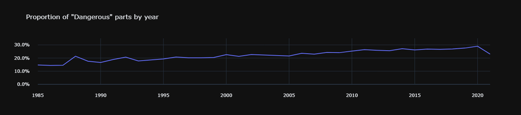

```python
fig = px.line(
    first_test_major_dang_proportion_by_year,
    x='year',
    y='Dangerous',
    title='Proportion of "Dangerous" parts by year'
)
fig.update_layout(
    width=900,
    height=300,
    yaxis=dict(
        title='',
        tickformat=".1%",
        range=[0, 0.35],
    ),
    xaxis=dict(title=''),
     margin=dict(
        pad=20
    )
)
fig.show()
```

```python
first_test_major_dang_proportion_by_make = (
    first_test_failed_items[['make', 'rfr_deficiency_category', 'passed']]
    .groupby('make', as_index=False)
    ['rfr_deficiency_category']
    .value_counts()
    .loc[lambda x: x['count'] > 0]
    .pivot_table(
        index='make',
        columns='rfr_deficiency_category',
        values='count',
        fill_value=0,
        observed=False
    )# если оставлю - подумать над числом мото
    .loc[lambda x: x['Dangerous'] + x['Major'] >= 200]
    .reset_index()
)
first_test_major_dang_proportion_by_make.columns.name = None
first_test_major_dang_proportion_by_make['dang_pct'] = (
    (first_test_major_dang_proportion_by_make['Dangerous']
    / (first_test_major_dang_proportion_by_make['Dangerous']
    + first_test_major_dang_proportion_by_make['Major'])).round(3)
)
first_test_major_dang_proportion_by_make = (
    first_test_major_dang_proportion_by_make.sort_values(by='dang_pct')
)
first_test_major_dang_proportion_by_make = (
    first_test_major_dang_proportion_by_make.merge(
        fail_rate_by_make[['make', 'fail_rate']], on='make', how='left'
    )
)
first_test_major_dang_proportion_by_make = first_test_major_dang_proportion_by_make.loc[first_test_major_dang_proportion_by_make['fail_rate']<= 0.2]
```

```python
# спросить гпт про это (удаление outlier)
first_test_major_dang_proportion_by_make[['dang_pct', 'fail_rate']].corr()
```

|  | dang_pct | fail_rate |
| --- | --- | --- |
| dang_pct | 1.000000 | -0.437448 |
| fail_rate | -0.437448 | 1.000000 |

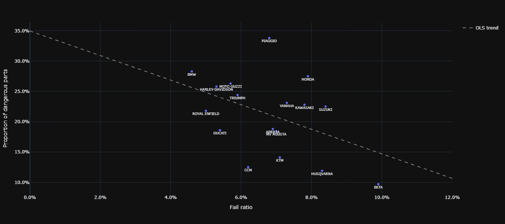

```python
fig = px.scatter(
    first_test_major_dang_proportion_by_make,
    y='dang_pct',
    x='fail_rate',
    text='make',
    hover_data={
        'make':True,
        'fail_rate': ':.1%',
        'dang_pct': ':.1%'}
    )
x = first_test_major_dang_proportion_by_make["fail_rate"]
y = first_test_major_dang_proportion_by_make["dang_pct"]

X = sm.add_constant(x)
model = sm.OLS(y, X).fit()

x_line = np.array([0, 0.12])
y_line = model.predict(sm.add_constant(x_line))

fig.add_scatter(
    x=x_line,
    y=y_line,
    mode="lines",
    name="OLS trend",
    line=dict(dash="dash",
             color='grey')
)
fig.update_layout(
    yaxis=dict(
        title='Proportion of dangerous parts',
        tickformat=".1%"
    ),
    xaxis=dict(
        title='Fail ratio',
        range=[0,0.12],
        tickformat=".1%",
        ),
    width=900,
    height=600,
)
fig.update_traces(
    textfont=dict(
        size=9,
    ),
    textposition='bottom center'
)
fig.show()
```

```python
# вроде бы есть обратная корреляция между fail rate и частью dangerous rfrs
```

```python
# скорее всего удалить  first_test_major_dang_proportion_by_mileage
```

```python
first_test_major_dang_proportion_by_mileage = (
first_test_failed_items
    [['make', 'rfr_deficiency_category']]
    .groupby(
        mileage_bins,
        observed=True,
        as_index=False
    )
    ['rfr_deficiency_category']
    .value_counts()
    .loc[lambda x: x['count'] > 0]
    .pivot_table(
        index='test_mileage',
        columns='rfr_deficiency_category',
        values='count',
        fill_value=0,
        observed=False
    )
    .reset_index()
)
first_test_major_dang_proportion_by_mileage['dang_pct'] = (
    first_test_major_dang_proportion_by_mileage['Dangerous']
    / (first_test_major_dang_proportion_by_mileage['Dangerous']
    + first_test_major_dang_proportion_by_mileage['Major'])
)
first_test_major_dang_proportion_by_mileage = (
    first_test_major_dang_proportion_by_mileage.sort_index()
)
first_test_major_dang_proportion_by_mileage.head(5)
```

| rfr_deficiency_category | test_mileage | Dangerous | Major | dang_pct |
| --- | --- | --- | --- | --- |
| 0 | 0-10000 | 3939.0 | 12979.0 | 0.232829 |
| 1 | 10000-30000 | 5719.0 | 18297.0 | 0.238133 |
| 2 | 30000-60000 | 2256.0 | 7116.0 | 0.240717 |
| 3 | 60000-90000 | 282.0 | 874.0 | 0.243945 |
| 4 | 90000+ | 45.0 | 171.0 | 0.208333 |

[figure not shown]

```python
fig = px.bar(
    first_test_major_dang_proportion_by_mileage,
    y='dang_pct',
    x='test_mileage',
    title='Proportion of "Dangerous" parts by year'
)
fig.update_layout(
    yaxis=dict(
        title='',
        ticksuffix="%"),
    xaxis=dict(
        title='',
        showticklabels=True,
        ),
# autosize=True,
    bargap=0.1,
    width=950,
    height=480,
    margin=dict(l=10, r=50, t=50, b=0, pad=5)
)
fig.update_layout(yaxis_tickformat = '.%')
fig.show()
```

### Rfr for vehicles produced in various decades

```python
first_use_year_bins = (
    pd.cut(
        first_test_failed_items.loc[
            first_test_details['first_use_date'].dt.year >= 1980,
            'first_use_date'].dt.year,
        [1980, 1990, 2000, 2010, 2020, 2022],
        right=False,
        labels=["1980-1990", "1990-2000", "2000-2010",
                "2010-2020", "2020-2021"])
)
first_use_year_bins.head(5)
```

```
4     2010-2020
5     2010-2020
6     2010-2020
9     2010-2020
10    2010-2020
Name: first_use_date, dtype: category
Categories (5, object): ['1980-1990' < '1990-2000' < '2000-2010' < '2010-2020' < '2020-2021']
```

```python
top_20_rfr_by_production_decade = (
    first_test_failed_items.groupby(
        [first_use_year_bins, 'section_name', 'item_name','rfr_desc'],
        as_index=False,
        observed=False
        )
    .size()
    .loc[lambda x: x['size'] > 0]
    .sort_values(by=['first_use_date', 'size'], ascending=[True, False])
    .groupby('first_use_date', observed=False)
    .head(20)
    .reset_index(drop=True)
)
top_20_rfr_by_production_decade['rank'] = (
    top_20_rfr_by_production_decade.groupby(
        'first_use_date', observed=False)
        ['size']
        .rank(method='dense', ascending=False)
)
top_20_rfr_by_production_decade.head(20)
```

|  | first_use_date | section_name | item_name | rfr_desc | size | rank |
| --- | --- | --- | --- | --- | --- | --- |
| 0 | 1980-1990 | Suspension | Shock absorbers | A shock absorber not functioning or leaking se... | 156 | 1.0 |
| 1 | 1980-1990 | Lamps and reflectors | Stop lamp | Stop lamp missing, inoperative or in the case ... | 80 | 2.0 |
| 2 | 1980-1990 | Lamps and reflectors | Headlamp | A headlamp missing, inoperative or more than ½... | 73 | 3.0 |
| 3 | 1980-1990 | Brakes | Roller brake test | Significant brake effort recorded with no brak... | 70 | 4.0 |
| 4 | 1980-1990 | Lamps and reflectors | Headlamp aim | The aim of a headlamp is not within limits lai... | 62 | 5.0 |
| 5 | 1980-1990 | Lamps and reflectors | Position lamp | A lamp missing or inoperative | 57 | 6.0 |
| 6 | 1980-1990 | Audible warning (horn) | Motorcycle audible warning (Horn) | Audible warning not working | 54 | 7.0 |
| 7 | 1980-1990 | Lamps and reflectors | Individual direction indicators | A direction indicator lamp missing, inoperativ... | 49 | 8.0 |
| 8 | 1980-1990 | Identification of the vehicle | Registration plate | Number plate does not conform to the specified... | 45 | 9.0 |
| 9 | 1980-1990 | Lamps and reflectors | Stop lamp | A stop lamp(s) does not illuminate by the oper... | 45 | 9.0 |
| 10 | 1980-1990 | Brakes | Roller brake test | Brake efficiency below minimum requirement | 43 | 10.0 |
| 11 | 1980-1990 | Lamps and reflectors | Rear reflectors | Reflector missing or reflecting white to the rear | 42 | 11.0 |
| 12 | 1980-1990 | Tyres | Condition | Tyre tread depth not in accordance with the re... | 40 | 12.0 |
| 13 | 1980-1990 | Lamps and reflectors | Headlamp aim | Projected beam image is obviously incorrect | 35 | 13.0 |
| 14 | 1980-1990 | Structure and attachments | Exhaust system | Exhaust system leaking or insecure | 34 | 14.0 |
| 15 | 1980-1990 | Lamps and reflectors | Registration plate lamp | A rear registration plate lamp or light source... | 32 | 15.0 |
| 16 | 1980-1990 | Brakes | Roller brake test | Excessive fluctuation in brake effort through ... | 31 | 16.0 |
| 17 | 1980-1990 | Lamps and reflectors | All direction indicators | A direction indicator lamp missing, inoperativ... | 31 | 16.0 |
| 18 | 1980-1990 | Brakes | Brake discs | Contaminated with oil, grease etc | 28 | 17.0 |
| 19 | 1980-1990 | Brakes | Brake pads | A brake lining or pad contaminated with oil, g... | 28 | 17.0 |

```python
(top_20_rfr_by_production_decade
    .pivot(
        index=['section_name', 'item_name', 'rfr_desc'],
        columns='first_use_date',
        values='rank')
    .sort_values(by=['2020-2021'])
    .fillna('-')
)
```

| section_name | item_name | first_use_date rfr_desc | 1980-1990 | 1990-2000 | 2000-2010 | 2010-2020 | 2020-2021 |
| --- | --- | --- | --- | --- | --- | --- | --- |
| Tyres | Condition | Tyre tread depth not in accordance with the requirements | 12.0 | 2.0 | 2.0 | 1.0 | 1.0 |
| Brakes | Brake pads | Brake lining or pad worn below 1.0mm | - | 10.0 | 3.0 | 3.0 | 2.0 |
| Lamps and reflectors | Rear reflectors | Reflector missing or reflecting white to the rear | 11.0 | 11.0 | 9.0 | 4.0 | 3.0 |
| Identification of the vehicle | Registration plate | Number plate does not conform to the specified requirements | 9.0 | 8.0 | 5.0 | 5.0 | 4.0 |
| Brakes | Roller brake test | Excessive fluctuation in brake effort through each wheel revolution | 16.0 | 14.0 | 13.0 | 8.0 | 5.0 |
| Suspension | Shock absorbers | A shock absorber not functioning or leaking severely | 1.0 | 1.0 | 1.0 | 2.0 | 6.0 |
| Lamps and reflectors | Headlamp aim | The aim of a headlamp is not within limits laid down in the requirements | 5.0 | 7.0 | 7.0 | 10.0 | 7.0 |
| Structure and attachments | Drive chain | A transmission belt, chain, sprocket or pulley excessively loose or worn | - | 15.0 | 15.0 | 7.0 | 8.0 |
| Lamps and reflectors | Registration plate lamp | A rear registration plate lamp or light source missing or inoperative in the case of a single lamp or all lamps | 15.0 | 16.0 | 10.0 | 11.0 | 9.0 |
|  | Headlamp | A headlamp missing, inoperative or more than ½ not functioning in the case of LED | 3.0 | 9.0 | 8.0 | 6.0 | 10.0 |
| Structure and attachments | Footrests | A footrest missing or insecure | - | - | - | 18.0 | 11.0 |
| Steering | Headbearings | Steering head bearings excessively stiff, notchy, or with excessive wear or play | - | - | - | 17.0 | 12.0 |
| Lamps and reflectors | Stop lamp | Stop lamp missing, inoperative or in the case of a multiple light source more than 1/2 not functioning | 2.0 | 3.0 | 4.0 | 9.0 | 13.0 |
| Audible warning (horn) | Motorcycle audible warning (Horn) | Audible warning not working | 7.0 | 12.0 | 12.0 | 12.0 | 14.0 |
| Lamps and reflectors | Stop lamp | A stop lamp(s) does not illuminate by the operation of both brake controls or remains on when the brakes are released | 9.0 | 13.0 | 14.0 | 16.0 | 15.0 |
| Brakes | Roller brake test | Brake efficiency below minimum requirement | 10.0 | 18.0 | 20.0 | 19.0 | 16.0 |
|  |  | Significant brake effort recorded with no brake applied indicating a binding brake | 4.0 | 4.0 | 11.0 | 15.0 | 17.0 |
| Suspension | Wheel bearings | A wheel bearing with excessive play | - | 19.0 | 19.0 | 14.0 | 18.0 |
| Lamps and reflectors | Individual direction indicators | A direction indicator lamp missing, inoperative or in the case of a multiple light source more than 1/2 not functioning | 8.0 | 5.0 | 6.0 | 13.0 | 19.0 |
| Structure and attachments | Drive chain | A transmission belt, chain, sprocket or pulley so loose or worn it is likely to fail | - | - | - | - | 20.0 |
| Brakes | Brake discs | Contaminated with oil, grease etc | 17.0 | - | - | - | - |
|  | Brake pads | A brake lining or pad contaminated with oil, grease etc | 17.0 | - | - | - | - |
| Lamps and reflectors | All direction indicators | A direction indicator lamp missing, inoperative or in the case of a multiple light source more than 1/2 not functioning | 16.0 | - | - | - | - |
|  | Headlamp aim | Projected beam image is obviously incorrect | 13.0 | 17.0 | 18.0 | - | - |
|  | Position lamp | A lamp missing or inoperative | 6.0 | 6.0 | 16.0 | - | - |
|  | Stop lamp | A stop lamp(s) remains on when the brakes are released | - | - | - | 20.0 | - |
| Structure and attachments | Exhaust system | Exhaust system leaking or insecure | 14.0 | - | - | - | - |
| Tyres | Valve stem | A tyre valve seriously damaged or misaligned likely which could cause sudden deflation of the tyre | - | 20.0 | 17.0 | - | - |

### Comparison of top failed parts across leading motorcycle brands

Now we'll try to figure out is there any difference between top 10 failed parts for top 10 brands, i.e do various brands have specific weak spots

```python
top_10_makers = first_test['make'].value_counts()[:10].index.to_list()
```

```python
top10_rfr_per_make_v1 = (
    first_test_failed_items.loc[
        first_test_failed_items['make'].isin(top_10_makers)
        ]
    .groupby(
        ['make', 'section_name',
        'item_name', 'rfr_desc'],
        as_index=False)
    .size()
    .sort_values(
        by=['make', 'size'],
        ascending=[True, False])
    .groupby('make')
    .head(10)
    .reset_index(drop=True)
)
top10_rfr_per_make_v1['rank'] = (
    top10_rfr_per_make_v1.groupby('make')['size']
    .rank(method='dense', ascending=False)
)
top10_rfr_per_make_v1.head(5)
```

|  | make | section_name | item_name | rfr_desc | size | rank |
| --- | --- | --- | --- | --- | --- | --- |
| 0 | BMW | Tyres | Condition | Tyre tread depth not in accordance with the re... | 420 | 1.0 |
| 1 | BMW | Brakes | Brake pads | Brake lining or pad worn below 1.0mm | 402 | 2.0 |
| 2 | BMW | Suspension | Shock absorbers | A shock absorber not functioning or leaking se... | 364 | 3.0 |
| 3 | BMW | Brakes | Roller brake test | Excessive fluctuation in brake effort through ... | 236 | 4.0 |
| 4 | BMW | Lamps and reflectors | Headlamp aim | The aim of a headlamp is not within limits lai... | 175 | 5.0 |

```python
top10_rfr_per_make_v1.pivot(
    index=['section_name', 'item_name', 'rfr_desc'],
    columns='make',
    values='rank'
)[top_10_makers].sort_values(by='HONDA').fillna('-')
```

| section_name | item_name | make rfr_desc | HONDA | YAMAHA | TRIUMPH | SUZUKI | KAWASAKI | BMW | HARLEY-DAVIDSON | DUCATI | KTM | ROYAL ENFIELD |
| --- | --- | --- | --- | --- | --- | --- | --- | --- | --- | --- | --- | --- |
| Suspension | Shock absorbers | A shock absorber not functioning or leaking severely | 1.0 | 2.0 | 3.0 | 1.0 | 1.0 | 3.0 | - | 3.0 | 5.0 | - |
| Tyres | Condition | Tyre tread depth not in accordance with the requirements | 2.0 | 1.0 | 1.0 | 2.0 | 2.0 | 1.0 | 2.0 | 1.0 | 8.0 | 1.0 |
| Brakes | Brake pads | Brake lining or pad worn below 1.0mm | 3.0 | 4.0 | 2.0 | 4.0 | 3.0 | 2.0 | 6.0 | - | - | - |
| Lamps and reflectors | Stop lamp | Stop lamp missing, inoperative or in the case of a multiple light source more than 1/2 not functioning | 4.0 | 9.0 | 10.0 | 3.0 | 8.0 | - | 5.0 | 8.0 | 6.0 | 2.0 |
| Structure and attachments | Drive chain | A transmission belt, chain, sprocket or pulley excessively loose or worn | 5.0 | - | - | - | 10.0 | - | - | - | - | 7.0 |
| Brakes | Roller brake test | Significant brake effort recorded with no brake applied indicating a binding brake | 6.0 | - | 8.0 | 7.0 | 4.0 | 6.0 | - | - | - | - |
| Lamps and reflectors | Headlamp aim | The aim of a headlamp is not within limits laid down in the requirements | 7.0 | 7.0 | 7.0 | 10.0 | - | 5.0 | 8.0 | - | 9.0 | 8.0 |
|  | Headlamp | A headlamp missing, inoperative or more than ½ not functioning in the case of LED | 8.0 | 8.0 | - | - | - | 7.0 | - | 9.0 | 4.0 | 9.0 |
| Suspension | Wheel bearings | A wheel bearing with excessive play | 9.0 | - | - | - | - | - | - | - | 3.0 | - |
| Lamps and reflectors | Stop lamp | A stop lamp(s) does not illuminate by the operation of both brake controls or remains on when the brakes are released | 10.0 | - | - | - | - | - | 9.0 | - | - | 5.0 |
| Audible warning (horn) | Motorcycle audible warning (Horn) | Audible warning not working | - | - | 6.0 | - | - | 9.0 | - | - | 4.0 | - |
| Brakes | Roller brake test | Brake efficiency below minimum requirement | - | - | - | - | - | - | - | 4.0 | - | 3.0 |
|  |  | Excessive fluctuation in brake effort through each wheel revolution | - | - | 4.0 | - | - | 4.0 | 7.0 | 6.0 | 7.0 | - |
| Identification of the vehicle | Registration plate | Number plate does not conform to the specified requirements | - | 5.0 | 5.0 | 8.0 | 7.0 | 8.0 | 1.0 | 5.0 | 2.0 | 6.0 |
| Lamps and reflectors | Individual direction indicators | A direction indicator lamp missing, inoperative or in the case of a multiple light source more than 1/2 not functioning | - | 6.0 | - | 5.0 | 9.0 | - | 10.0 | 7.0 | - | 8.0 |
|  | Position lamp | A lamp missing or inoperative | - | - | - | - | - | 10.0 | - | - | - | - |
|  | Rear reflectors | Reflector missing or reflecting white to the rear | - | 3.0 | 9.0 | 9.0 | 5.0 | - | 4.0 | 2.0 | 1.0 | 4.0 |
|  | Registration plate lamp | A rear registration plate lamp or light source missing or inoperative in the case of a single lamp or all lamps | - | 10.0 | - | 6.0 | 6.0 | - | - | 10.0 | - | - |
|  | Stop lamp | A stop lamp(s) remains on when the brakes are released | - | - | - | - | - | - | 3.0 | - | - | - |